# Annual Developer Survey

## Jan, 2021

### Summary

The dataset that we wrangle, analyse and visualize is the annual StackOverflow developer survey. We use the 2018 and 2020 surveys to analyse changes in the popularity of programming languages. Two of the survey questions are asking about programming languages users have done extensive development work in over the past year, and which languages they want to work in over the next year.

We use the 2020 survey to analyse correlations between programming languages and between other frameworks, libraries, and tools (i.e., technologies) users have done extensive development work in over the past year. Furthermore, we filter the data for respondents who perform the developer role of *Data Scientist or Machine Learning Specialist*. We analyse what additional developer roles they perform, what languages they prefer and what other technologies they use.

Finally, we use a linear machine learning model to find coefficients with significant impact on the salaries of professional developers in the United States.

### Motivation

#### What can Data Scientists / Machine Learning Specialists learn from Stack Overflow’s annual Developer Survey?

First, we want to learn from the peer group Data Scientists or Machine Learning Specialists. What programming languages do they use, what additional developer roles do they perform and what tools do they prefer. Second, we want to analyse general trends in the popularity of programming languages. What languages have gained momentum between 2018 and 2020? Finally, we want to use a linear machine learning model to gauge the impact of developer roles, language proficiency and experience in the usage of other tools and technologies on the salary of professional developers. Does it pay to learn a new niche language like Julia, or does Python or R suffice?

### Data Description

In February 2020 nearly 65,000 developers told Stack Overflow how they learn and level up, which tools they’re using, and what they want. The 2020 survey focuses on seeking diverse representation while asking for information ranging from technologies and behavior to questions that will help to improve the Stack Overflow community for everybody who codes. For almost a decade, Stack Overflow’s annual Developer Survey is the largest survey of people who code around the world.

Since 2011, Stack Overflow, a popular Q&A site for developers, has surveyed a large number of users. The annual surveys consist of questions with numerical answers (e.g. age, salary) and of questions with categorical answers from multiple choice options ( "choose one" or "choose all that apply" ). With nearly 65,000 responses fielded from over 180 countries and dependent territories, the 2020 Annual Developer Survey examines different aspects of the developer experience from career satisfaction and job search to education and opinions on open source software.

Founded in 2008, Stack Overflow’s public platform is used by nearly everyone who codes to learn, share their knowledge, collaborate, and build their careers. For almost a decade, Stack Overflow’s annual Developer Survey has been the largest survey of people who code around the world.

Notably, the 2020 survey was conducted in February, before the World Health Organization declared the coronavirus outbreak to be a pandemic.

## Source

The anonymized results of the survey are available for download under the **Open Database License (ODbL)**. StackOverflow is looking forward to seeing what we find—if we share on social media, we should tag them!

> - https://insights.stackoverflow.com/survey/2020
> - https://insights.stackoverflow.com/survey/2018

> Here you can download the datafiles (.csv format) for each of the annual developer surveys since 2011:
> - https://insights.stackoverflow.com/survey

> For brief description of the most popular programming languages in the 2020 survey:
> - https://www.businessinsider.com/stack-overflow-developer-survey-14-most-loved-programming-languages-2020-5?r=DE&IR=T#5-go-10

## Key Results

### Here are a few of the top takeaways from this report.

> **Data Scientist/Machine Learning Specialist** frequently perform additional software developer roles as well. Almost half are **Developer backend** and 37 % are **Developer fullstack**. Other popular developer roles performed by DS/ML specialists are **Data or business analyst** ( 33 %) and **Engineer data** ( 30 %). About a third of DS/ML specialists are **Academic researcher** or **Scientist**.

> **Python** is by far the most popular programming language for Data Science and Machine Learning (used by 80%). Structured Query Language **(SQL)** is used by 60 % and half use the languages **HTML/CSS** and **JavaScript** for web development. About 40 % use **Bash/Shell/PowerShell** for command line Interface and 28 % use the **R language** for data analysis. Already 4 % use **Julia** , a language that first appeared in 2012.

> The most popular other technologies used by DS/ML Specialist are **Pandas** (50 %) , **Tensorflow** (38 %) , **Keras** (27 %) , **Node.js** (26 %) and **Torch/PyTorch** (20 %).

> The order of the 5 most popular languages in 2018 and 2020 remain unchanged, but all 5 are losing market share compared to 2018. **JavaScript** (-2.2 %) remains the most popular programming language with developers, followed by **HTML/CSS** (-2.0%) , **SQL** (-2.3%) , **Java** (-5.1 %) and **Bash/Shell/PowerShell** (-6.7 %). Languages gaining popularity are **Python** (+5.3 % ) ,**TypeScript** (+8.0 %) , **Go** (+1.7 %), **VBA** **(+1.2 %)** , **Kotlin** (+3.3 %) , **Rust** (+2.7 %) and **Julia** (+0.4 %).

> The 5 most desired languages developers wanted to work with in 2020 are **Python** (46.2%), **JavaScript** (45.3%), **HTML/CSS** (35.9%), **SQL** (34,6 %) and **Java** (22.9 %).

> We have used the 2020 answers from professional developers in the USA to train a linear machine learning model with Python scikit-learn. Niche programming languages like **Dart** or **Julia** have a strong impact on salary expectations. The two programming languages most popular with Data Scientists / Machine Learning specialists, **Python** and **R**, have a moderately strong and a weak impact on expected salary, respectively. Knowledge of command line Interface languages **Bash/Shell/PowerShell** has a moderate impact and proficiency in **SQL** has only a weak impact on forecasted salary. Using the machine learning tools **Torch/PyTorch** and **Keras** have a moderately strong impact on expected salaries, while using the tools **TensorFlow** and **Pandas** only have a weak impact on the response variable. However, proficiency in the Big Data tools **Apache Spark** and **Hadoop** have a moderate impact on expected salaries.

**I.** **Preliminary Data Wrangling**

- Calculating permutations for multiple choice questions and responses

**II.** **What is the structure of the dataset?**

**III.** **Exploration of numerical variables**

- Distribution of salaries

**IV.** **Exploration of categorical variables**

- Project Management Methodologies

**(1)** *Research Question No.1: What additional developer roles do Data Scientist/Machine_Learning_specialist perform?*

**(2)** *Research Question No.2: What programming languages do Data Scientist/Machine Learning Specialist use ?*

- Correlation between technologies

**(3)** *Research Question No.3:What technologies do Data Scientist/Machine Learning Specialist use ?*

- Correlation between languages

**V.** **Intertemporal exploration**

**(4)** *Research Question No.4: What languages are gaining popularity ?*

**VI.** **Machine learning**

**(5)** *Research Question No.5: What variables have a strong impact on the salaries of professional software developers in the USA ?*

**VII.** **Conclusion**

# I. Preliminary Wrangling

We load all the necessary libraries.

```python
# import all packages and set plots to be embedded inline
import numpy as np
import pandas as pd
import matplotlib.pyplot as plt
from sklearn.linear_model import LinearRegression
from sklearn.model_selection import train_test_split
from sklearn.metrics import r2_score, mean_squared_error
#import AllTogether as t
import seaborn as sns
%matplotlib inline
from itertools import chain
```

## Gathering Data

We load the datasets for the Developer Surveys 2018 and 2020 into a pandas dataframe and print statistics.

```python
# load the .csv file from the current directory
df2018 = pd.read_csv('./survey_results_public2018.csv')
df2020 = pd.read_csv('./survey_results_public2020.csv')
df2020.head()
```

|  | Respondent | MainBranch | Hobbyist | Age | Age1stCode | CompFreq | CompTotal | ConvertedComp | Country | CurrencyDesc | ... | SurveyEase | SurveyLength | Trans | UndergradMajor | WebframeDesireNextYear | WebframeWorkedWith | WelcomeChange | WorkWeekHrs | YearsCode | YearsCodePro |
| --- | --- | --- | --- | --- | --- | --- | --- | --- | --- | --- | --- | --- | --- | --- | --- | --- | --- | --- | --- | --- | --- |
| 0 | 1 | I am a developer by profession | Yes | NaN | 13 | Monthly | NaN | NaN | Germany | European Euro | ... | Neither easy nor difficult | Appropriate in length | No | Computer science, computer engineering, or sof... | ASP.NET Core | ASP.NET;ASP.NET Core | Just as welcome now as I felt last year | 50.0 | 36 | 27 |
| 1 | 2 | I am a developer by profession | No | NaN | 19 | NaN | NaN | NaN | United Kingdom | Pound sterling | ... | NaN | NaN | NaN | Computer science, computer engineering, or sof... | NaN | NaN | Somewhat more welcome now than last year | NaN | 7 | 4 |
| 2 | 3 | I code primarily as a hobby | Yes | NaN | 15 | NaN | NaN | NaN | Russian Federation | NaN | ... | Neither easy nor difficult | Appropriate in length | NaN | NaN | NaN | NaN | Somewhat more welcome now than last year | NaN | 4 | NaN |
| 3 | 4 | I am a developer by profession | Yes | 25.0 | 18 | NaN | NaN | NaN | Albania | Albanian lek | ... | NaN | NaN | No | Computer science, computer engineering, or sof... | NaN | NaN | Somewhat less welcome now than last year | 40.0 | 7 | 4 |
| 4 | 5 | I used to be a developer by profession, but no... | Yes | 31.0 | 16 | NaN | NaN | NaN | United States | NaN | ... | Easy | Too short | No | Computer science, computer engineering, or sof... | Django;Ruby on Rails | Ruby on Rails | Just as welcome now as I felt last year | NaN | 15 | 8 |

5 rows × 61 columns

```python
# high-level overview of data shape and composition
print(df2018.shape)
```

```
(98855, 129)
```

```python
# high-level overview of data shape and composition
print(df2020.shape)
```

```
(64461, 61)
```

We have successfully gathered the data. Next, we will be analysing the data.

## Assessing Data

➔ Assess data visually and programmatically using pandas

➔ Distinguish between dirty data (content or “quality” issues) and messy data (structural or “tidiness” issues)

➔ Identify data quality issues and categorize them using metrics: validity, accuracy, completeness, and consistency

You can assess data for:

- *QUALITY:* issues with content. Low quality data is also known as dirty data. (e.g. inaccurate data, corrupted data, duplicate data)
- *TIDINESS:* issues with structure that prevent easy analysis. Untidy data is also known as messy data.

*QUALITY dimensions: (the four main)*

- *Completeness:* do we have all of the records that we should? Do we have missing records or not? Are there specific rows, columns, or cells missing?
- *Validity:* we have the records, but they're not valid, i.e., they don't conform to a defined schema. A schema is a defined set of rules for data. These rules can be real-world constraints (e.g. negative height is impossible) and table-specific constraints (e.g. unique key constraints in tables).
- *Accuracy:* inaccurate data is wrong data that is valid. It adheres to the defined schema, but it is still incorrect. Example: a patient's weight that is 5 lbs too heavy because the scale was faulty.
- *Consistency:* inconsistent data is both valid and accurate, but there are multiple correct ways of referring to the same thing. Consistency, i.e., a standard format, in columns that represent the same data across tables and/or within tables is desired.

*TIDINESS requires:*

- Each variable forms a column.
- Each observation forms a row.
- Each type of observational unit forms a table.

```python
df2018.info()
```

```
<class 'pandas.core.frame.DataFrame'>
RangeIndex: 98855 entries, 0 to 98854
Columns: 129 entries, Respondent to SurveyEasy
dtypes: float64(41), int64(1), object(87)
memory usage: 97.3+ MB
```

The Developer Survey 2018 **`df2018`** contains 129 variables (columns) with 98855 observations (rows). There are 42 numeric variables and 87 variables are categorical (i.e. type = object).

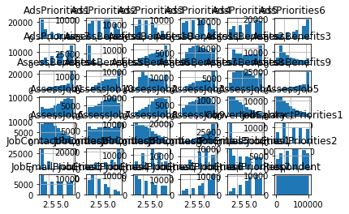

```python
df2018.hist(); # show histograms or all the numerical variables
```

We will only be using a limited number of the variables from the 2018 Survey going forward because we will be using the most recent data.

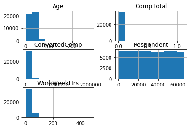

```python
df2020.hist(); # show histograms or all the numerical variables
```

```python
df2020.info()
```

```
<class 'pandas.core.frame.DataFrame'>
RangeIndex: 64461 entries, 0 to 64460
Data columns (total 61 columns):
Respondent                      64461 non-null int64
MainBranch                      64162 non-null object
Hobbyist                        64416 non-null object
Age                             45446 non-null float64
Age1stCode                      57900 non-null object
CompFreq                        40069 non-null object
CompTotal                       34826 non-null float64
ConvertedComp                   34756 non-null float64
Country                         64072 non-null object
CurrencyDesc                    45472 non-null object
CurrencySymbol                  45472 non-null object
DatabaseDesireNextYear          44070 non-null object
DatabaseWorkedWith              49537 non-null object
DevType                         49370 non-null object
EdLevel                         57431 non-null object
Employment                      63854 non-null object
Ethnicity                       45948 non-null object
Gender                          50557 non-null object
JobFactors                      49349 non-null object
JobSat                          45194 non-null object
JobSeek                         51727 non-null object
LanguageDesireNextYear          54113 non-null object
LanguageWorkedWith              57378 non-null object
MiscTechDesireNextYear          42379 non-null object
MiscTechWorkedWith              40314 non-null object
NEWCollabToolsDesireNextYear    47287 non-null object
NEWCollabToolsWorkedWith        52883 non-null object
NEWDevOps                       42686 non-null object
NEWDevOpsImpt                   41732 non-null object
NEWEdImpt                       48465 non-null object
NEWJobHunt                      42286 non-null object
NEWJobHuntResearch              41022 non-null object
NEWLearn                        56156 non-null object
NEWOffTopic                     50804 non-null object
NEWOnboardGood                  42623 non-null object
NEWOtherComms                   57205 non-null object
NEWOvertime                     43231 non-null object
```

[output cut: 11 more lines]

```
SOComm                          56476 non-null object
SOPartFreq                      46792 non-null object
SOVisitFreq                     56970 non-null object
SurveyEase                      51802 non-null object
SurveyLength                    51701 non-null object
Trans                           49345 non-null object
UndergradMajor                  50995 non-null object
WebframeDesireNextYear          40024 non-null object
WebframeWorkedWith              42279 non-null object
WelcomeChange                   52683 non-null object
WorkWeekHrs                     41151 non-null float64
YearsCode                       57684 non-null object
YearsCodePro                    46349 non-null object
dtypes: float64(4), int64(1), object(56)
memory usage: 30.0+ MB
```

```python
df2018.nunique() #  show no. of unique entries in each column
```

```
Respondent                     98855
Hobby                              2
OpenSource                         2
Country                          183
Student                            3
Employment                         6
FormalEducation                    9
UndergradMajor                    12
CompanySize                        8
DevType                         9568
YearsCoding                       11
YearsCodingProf                   11
JobSatisfaction                    7
CareerSatisfaction                 7
HopeFiveYears                      7
JobSearchStatus                    3
LastNewJob                         5
AssessJob1                        10
AssessJob2                        10
AssessJob3                        10
AssessJob4                        10
AssessJob5                        10
AssessJob6                        10
AssessJob7                        10
AssessJob8                        10
AssessJob9                        10
AssessJob10                       10
AssessBenefits1                   11
AssessBenefits2                   11
AssessBenefits3                   11
                               ...
EthicsResponsible                  3
EthicalImplications                3
StackOverflowRecommend            11
StackOverflowVisit                 6
StackOverflowHasAccount            3
StackOverflowParticipate           6
StackOverflowJobs                  3
StackOverflowDevStory              4
StackOverflowJobsRecommend        11
StackOverflowConsiderMember        3
HypotheticalTools1                 5
HypotheticalTools2                 5
HypotheticalTools3                 5
HypotheticalTools4                 5
HypotheticalTools5                 5
WakeTime                          11
HoursComputer                      5
HoursOutside                       5
SkipMeals                          4
ErgonomicDevices                  15
Exercise                           4
Gender                            15
SexualOrientation                 14
EducationParents                   9
RaceEthnicity                     71
Age                                7
Dependents                         2
MilitaryUS                         2
SurveyTooLong                      3
SurveyEasy                         5
Length: 129, dtype: int64
```

In the Developer Survey 2018 **`df2018`** most of the 129 `variables` have a limited number of unique entries. Presumably, the multiple choice questions for the categorical variables only allow **one answer each**.

However, the variable `DevType` has a large number of unique entries, because most respondants stated multiple developer roles.

```python
df2018.groupby('DevType').mean()
```

[output not shown]

9568 rows × 42 columns

Let us look at the number of unique entries for the 61 variables of the Survey 2020 **`df2020`** .

```python
df2020.nunique() #  show no. of unique entries in each column
```

```
Respondent                      64461
MainBranch                          5
Hobbyist                            2
Age                               110
Age1stCode                         63
CompFreq                            3
CompTotal                        3003
ConvertedComp                    6958
Country                           183
CurrencyDesc                      142
CurrencySymbol                    141
DatabaseDesireNextYear           3193
DatabaseWorkedWith               2808
DevType                          8269
EdLevel                             9
Employment                          7
Ethnicity                         208
Gender                              7
JobFactors                        230
JobSat                              5
JobSeek                             3
LanguageDesireNextYear          16243
LanguageWorkedWith              14256
MiscTechDesireNextYear           5216
MiscTechWorkedWith               2730
NEWCollabToolsDesireNextYear     1277
NEWCollabToolsWorkedWith         1153
NEWDevOps                           3
NEWDevOpsImpt                       5
NEWEdImpt                           5
                                ...
NEWJobHuntResearch                 63
NEWLearn                            4
NEWOffTopic                         3
NEWOnboardGood                      3
NEWOtherComms                       2
NEWOvertime                         5
NEWPurchaseResearch                63
NEWPurpleLink                       4
NEWSOSites                         61
NEWStuck                          444
OpSys                               4
OrgSize                             9
PlatformDesireNextYear           7471
PlatformWorkedWith               6287
PurchaseWhat                        3
Sexuality                          14
SOAccount                           3
SOComm                              6
SOPartFreq                          6
SOVisitFreq                         6
SurveyEase                          3
SurveyLength                        3
Trans                               2
UndergradMajor                     12
WebframeDesireNextYear           3986
WebframeWorkedWith               3789
WelcomeChange                       6
WorkWeekHrs                       157
YearsCode                          52
YearsCodePro                       52
Length: 61, dtype: int64
```

## Calculating permutations for multiple choice questions and responses :

The survey 2020 **`df2020`** has a smaller number of variables than the survey 2018 **`df2018`** . Many of the variables in **`df2020`** have a high number of unique entries, presumably because the respondants can choose more than one answer </font> **(i.e. choose all that apply)**:  
.

However, the number of possible combinations rises exponentially with the number of options to choose from. If there are *'n'* binary options you can tick (checked box or blank box), than there are:

\begin{equation} No. of combinations = 2^n - 1 \end{equation}

possible answers (i.e. unique entries). The −1 is the option where all fields are left blank, which we want to excluse.

> For example, the variable **`df2020`** `Gender` has 7 unique entries, build from different combinations of the three binary options *`Man`* , *`Woman`* and *`Non-binary, genderqueer, or gender non-conforming`* .

> In this example, all the possible combinations can be calculated: 2 *2* 2 - 1 = 7

https://math.stackexchange.com/questions/3282038/calculating-permutations-for-multiple-questions-and-responses

```python
df2020.groupby('Gender').mean()
```

| Gender | Respondent | Age | CompTotal | ConvertedComp | WorkWeekHrs |
| --- | --- | --- | --- | --- | --- |
| Man | 28970.066394 | 30.905800 | 3.414358e+08 | 103615.911778 | 40.827825 |
| Man;Non-binary, genderqueer, or gender non-conforming | 32648.719008 | 29.574074 | 1.813509e+05 | 88912.375000 | 38.659091 |
| Non-binary, genderqueer, or gender non-conforming | 31202.314286 | 28.842342 | 3.668910e+28 | 116016.975410 | 38.735632 |
| Woman | 31963.561134 | 30.139910 | 5.675897e+05 | 98300.480651 | 39.566129 |
| Woman;Man | 30037.881579 | 25.520833 | 3.703953e+09 | 76289.777778 | 40.765625 |
| Woman;Man;Non-binary, genderqueer, or gender non-conforming | 27786.961538 | 41.357143 | 1.000000e+48 | 254225.700000 | 51.692308 |
| Woman;Non-binary, genderqueer, or gender non-conforming | 33931.543478 | 27.345238 | 2.533925e+05 | 89008.363636 | 40.966102 |

In contrast, the number of possible combinations (i.e. unique entries) is lower when only one or a certain number of options can be selected.

We can calculate the number of possible combinations of choosing x options out of n possible answers (i.e. n choose k):

$\mathbf{\text{Binomial coefficient ( read n choose k)}}$

\begin{equation} No. of possibleCombinations = {n \choose k} = \frac{n!}{x!(n-k)!} \end{equation}

When only one option can be choosen </font> **(i.e. choose one)**:

\begin{equation} No. of combinations = {n \choose 1} = n \end{equation}

>

> https://www.calculatorsoup.com/calculators/discretemathematics/combinations.php?n=3&r=3&action=solve

## Quality problem

> *Rule: Consistency*
> - (Q1) **`df2018`** and **`df2020`** contain missing values (NANs).

```python
no_nulls = set(df2018.columns[df2018.isnull().mean()==0])#Provide a set of columns with 0 missing values.
no_nulls
```

```
{'Hobby', 'OpenSource', 'Respondent'}
```

In **`df2018`** there are only 3 variables ( i.e. columns) without missing values in at least one observation (i.e. row).

Let us look at **`df2020`**

```python
no_nulls = set(df2020.columns[df2020.isnull().mean()==0])#Provide a set of columns with 0 missing values.
no_nulls
```

```
{'Respondent'}
```

## **Respondent** (Definition)

> Randomized respondent ID number (not in order of survey response time).

In **`df2020`** there is only 1 variable ( i.e. column) without missing values in at least one observation.

## Quality problem

> *Rule: Consistency*
> - (Q2) **`df2020`** variables (i.e. columns) `Age1stCode` , `YearsCode` and `YearsCodePro` contain dtype=object, rather than numerical values.

## **Age1stCode** (Definition)

> At what age did you write your first line of code or program? (e.g., webpage, Hello World, Scratch project)

```python
df2020.Age1stCode.unique()
```

```
array(['13', '19', '15', '18', '16', '14', '12', '20', '42', '8', '25',
       '22', '30', '17', '21', '10', '46', '9', '7', '11', '6', nan, '31',
       '29', '5', 'Younger than 5 years', '28', '38', '23', '27', '41',
       '24', '53', '26', '35', '32', '40', '33', '36', '54', '48', '56',
       '45', '44', '34', 'Older than 85', '39', '51', '68', '50', '37',
       '47', '43', '52', '85', '64', '55', '58', '49', '76', '72', '73',
       '83', '63'], dtype=object)
```

## **YearsCode** (Definition)

> Including any education, how many years have you been coding in total?

```python
df2020.YearsCode.unique()
```

```
array(['36', '7', '4', '15', '6', '17', '8', '10', '35', '5', '37', '19',
       '9', '22', '30', '23', '20', '2', 'Less than 1 year', '3', '13',
       '25', '16', '43', '11', '38', '33', nan, '24', '21', '12', '40',
       '27', '50', '46', '14', '18', '28', '32', '44', '26', '42', '31',
       '34', '29', '1', '39', '41', '45', 'More than 50 years', '47',
       '49', '48'], dtype=object)
```

## **YearsCodePro** (Definition)

> NOT including education, how many years have you coded professionally (as a part of your work)?

```python
df2020.YearsCodePro.unique()
```

```
array(['27', '4', nan, '8', '13', '2', '7', '20', '1', '23', '3', '12',
       '17', '18', '10', '14', '29', '6', '28', '9', '15', '11', '16',
       '25', 'Less than 1 year', '5', '21', '19', '35', '24', '32', '22',
       '30', '38', '26', '40', '33', '31', 'More than 50 years', '34',
       '36', '39', '37', '41', '45', '47', '42', '46', '50', '43', '44',
       '48', '49'], dtype=object)
```

## Tidiness problem

> *Rule: Each variable forms a column*
> - (Q3) **`df2020`** column `DevType` contains a combination of all the developer types a respondent provided in the questionnaire.

## **DevType** (Definition)

> Which of the following describe you? Please select all that apply.

```python
df2020.DevType.head(10)
```

```
0    Developer, desktop or enterprise applications;...
1              Developer, full-stack;Developer, mobile
2                                                  NaN
3                                                  NaN
4                                                  NaN
5      Designer;Developer, front-end;Developer, mobile
6    Developer, back-end;Developer, front-end;Devel...
7    Developer, back-end;Developer, desktop or ente...
8                                Developer, full-stack
9    Database administrator;Developer, full-stack;D...
Name: DevType, dtype: object
```

## Tidiness problem

> *Rule: Each variable forms a column*
> - (Q4) **`df2020`** column `MiscTechWorkedWith` contains a combination of all the technology types provided in the multiple choice question of the survey.

## **MiscTechWorkedWith & MiscTechDesireNextYear** (Definitions)

> Which other frameworks, libraries, and tools have you done extensive development work in over the past year, and which do you want to work in over the next year? (If you both worked with the framework and want to continue to do so, please check both boxes in that row.)

```python
df2020.MiscTechWorkedWith.head(25)
```

```
0                    .NET;.NET Core
1                      React Native
2                               NaN
3                               NaN
4                           Ansible
5                               NaN
6                               NaN
7                           Ansible
8                               NaN
9                            Pandas
10                          Node.js
11                             .NET
12                              NaN
13                          Node.js
14                              NaN
15                              NaN
16                     .NET;Node.js
17                              NaN
18           .NET;.NET Core;Node.js
19                          Node.js
20    Node.js;React Native;Unity 3D
21                              NaN
22                             .NET
23                              NaN
24                              NaN
Name: MiscTechWorkedWith, dtype: object
```

## Tidiness problem

> *Rule: Each variable forms a column*
> - (Q5) **`df2018`** and **`df2020`** columns `LanguageWorkedWith` and `LanguageDesireNextYear` contain a combination of all the programming languages that a developer uses or would like to learn/use next year.

## **LanguageWorkedWith & LanguageDesireNextYear** (Definitions)

> Which programming, scripting, and markup languages have you done extensive development work in over the past year, and which do you want to work in over the next year? (If you both worked with the language and want to continue to do so, please check both boxes in that row.)

```python
df2020.LanguageWorkedWith.head(5)
```

```
0      C#;HTML/CSS;JavaScript
1            JavaScript;Swift
2    Objective-C;Python;Swift
3                         NaN
4           HTML/CSS;Ruby;SQL
Name: LanguageWorkedWith, dtype: object
```

```python
df2020.LanguageDesireNextYear.head(5)
```

```
0      C#;HTML/CSS;JavaScript
1                Python;Swift
2    Objective-C;Python;Swift
3                         NaN
4             Java;Ruby;Scala
Name: LanguageDesireNextYear, dtype: object
```

Now let us address the problems that we have identified.

## Cleaning Data

➔ Identify each step of the data cleaning process (defining, coding, and testing)

➔ Clean data using Python and pandas

➔ Test cleaning code visually and programmatically using Python

We start by copying the two annual dataframes. This way we can reverse all changes done during cleaning.

```python
df2018_clean = df2018.copy()
df2020_clean = df2020.copy()
```

We should start the cleaning data process with data tidying (i.e. structuring datasets).

## Quality problem

> *Rule: Consistency*
> - (Q1) **`df2018`** and **`df2020`** contain missing values (NANs).

#### Define

- Remove missing values (i.e. NANs) from **`df2018`** and **`df2020`** .

#### Code

```python
# Create a dataframe without NAN values
df2018_new = df2018_clean.dropna()
df2018_new.shape
```

```
(6, 129)
```

</font> ***There is a problem !***  
There are only 6 observations in **`df2018`** without missing values in at least one variable.

In the 2018 developer survey, most respondants left some multiple choice questions unanswered.

Let us have a look at **`df2020`**.

```python
# Create a dataframe without NAN values
df2020_new = df2020_clean.dropna()
df2020_new.shape
```

```
(4213, 61)
```

*Not much better, there still is a problem*. There are only 4213 observations in **`df2020`** without missing values in at least one variable.

</font> ***Solution***  
In **`df2018`** and **`df2020`** we keep the NANs, because most respondants leave some questions unanswered and we do not want to miss any other information provided by respondants. However, later we will be analysing variables like `LanguageWorkedWith` and we will be deleting NANs in rows of those variables without affecting other variables (i.e. we don't delete entire rows for all variables).

#### Test

```python
df2018_clean.LanguageWorkedWith.isnull().sum()
```

```
20521
```

```python
df2020_clean.LanguageWorkedWith.isnull().sum()
```

```
7083
```

## Quality problem

> *Rule: Consistency*
> - (Q2) **`df2020`** variables (i.e. columns) `Age1stCode` , `YearsCode` and `YearsCodePro` contain dtype=object, rather than numerical values.

#### Define

- Change string observations (i.e. pandas type 'object') of variable `Age1stCode` to numerical.
- Change string observations (i.e. pandas type 'object') of variable `YearsCode` to numerical.
- Change string observations (i.e. pandas type 'object') of variable `YearsCodePro` to numerical.

#### Code

```python
# Replace the the strings with numerical values.
df2020_clean['Age1stCode']   = df2020_clean['Age1stCode'].replace(['Younger than 5 years','Older than 85'],['4','85'])
df2020_clean['YearsCode']    = df2020_clean['YearsCode'].replace(['Less than 1 year','More than 50 years'],['0.5','50'])
df2020_clean['YearsCodePro'] = df2020_clean['YearsCodePro'].replace(['Less than 1 year','More than 50 years'],['0.5','50'])

#df2020new = pd.to_numeric(df2020.YearsCode)
df2020_clean['Age1stCode']        = pd.to_numeric(df2020_clean['Age1stCode'])
df2020_clean['YearsCode']         = pd.to_numeric(df2020_clean['YearsCode'])
df2020_clean['YearsCodePro']      = pd.to_numeric(df2020_clean['YearsCodePro'])
```

#### Test

```python
df2020_clean.describe() # The variables `Age1stCode` ,  `YearsCode` and `YearsCodePro` are of type float now.
```

|  | Respondent | Age | Age1stCode | CompTotal | ConvertedComp | WorkWeekHrs | YearsCode | YearsCodePro |
| --- | --- | --- | --- | --- | --- | --- | --- | --- |
| count | 64461.000000 | 45446.000000 | 57900.000000 | 3.482600e+04 | 3.475600e+04 | 41151.000000 | 57684.000000 | 46349.000000 |
| mean | 32554.079738 | 30.834111 | 15.410121 | 3.190464e+242 | 1.037561e+05 | 40.782174 | 12.713135 | 8.514358 |
| std | 18967.442360 | 9.585392 | 5.289951 | inf | 2.268853e+05 | 17.816383 | 9.699281 | 7.875942 |
| min | 1.000000 | 1.000000 | 4.000000 | 0.000000e+00 | 0.000000e+00 | 1.000000 | 0.500000 | 0.500000 |
| 25% | 16116.000000 | 24.000000 | 12.000000 | 2.000000e+04 | 2.464800e+04 | 40.000000 | 6.000000 | 3.000000 |
| 50% | 32231.000000 | 29.000000 | 15.000000 | 6.300000e+04 | 5.404900e+04 | 40.000000 | 10.000000 | 6.000000 |
| 75% | 49142.000000 | 35.000000 | 18.000000 | 1.250000e+05 | 9.500000e+04 | 44.000000 | 17.000000 | 12.000000 |
| max | 65639.000000 | 279.000000 | 85.000000 | 1.111111e+247 | 2.000000e+06 | 475.000000 | 50.000000 | 50.000000 |

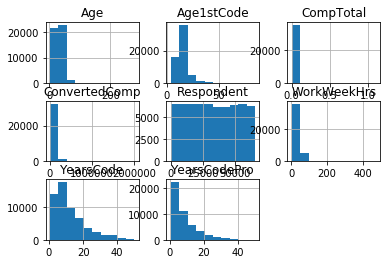

```python
df2020_clean.hist();
```

## Tidiness problem

> *Rule: Each variable forms a column*
> - (Q3) **`df2020`** column `DevType` contains a combination of all the developer types provided in the multiple choice question of the survey.

#### Define

- Create a list of all the different developer types provided in the multiple choice questionnaire of the survey.
- Create new columns in **`df2020`** of type boolean for each developer type listed in `DevType` .
- Replace white spaces and special characters in the column names to facilitate access via dot notation
- Create a new dataframe **`f2020_DevType`** that consists of the column `DevType` and the boolean variables mapped from **`df2020`** `DevType`.
- Delete NANs in **`f2020_DevType`**
- Delete **`df2020`** column `DevType`, because all of the information is now provided in the new boolean variables (i.e. columns) for each of the developer types.

#### Code

Create a list of all the developer types provided in the multiple choice question of the survey.

```python
DeveloperType = df2020_new.DevType.unique()

txt = []

for i in range(len(DeveloperType)):
    name = (DeveloperType[i].split(";"))
    txt.append(name)

DevType = set(list(chain.from_iterable(txt))) # The data type SET makes sure that
                                              # every developer type only appears once

DevType
```

```
{'Academic researcher',
 'Data or business analyst',
 'Data scientist or machine learning specialist',
 'Database administrator',
 'Designer',
 'DevOps specialist',
 'Developer, QA or test',
 'Developer, back-end',
 'Developer, desktop or enterprise applications',
 'Developer, embedded applications or devices',
 'Developer, front-end',
 'Developer, full-stack',
 'Developer, game or graphics',
 'Developer, mobile',
 'Educator',
 'Engineer, data',
 'Engineer, site reliability',
 'Engineering manager',
 'Marketing or sales professional',
 'Product manager',
 'Scientist',
 'Senior executive/VP',
 'System administrator'}
```

We want to create new columns for each of the developer types provided in the survey. The variables are of type boolean.

```python
def add_DevType(df):
    for name in DevType:
        df2020_clean[name] = False
        df2020_clean[name] = df2020_clean[df2020_clean['DevType'].str.contains(name, na=False)]
        df2020_clean[name] = (df2020_clean[name] > 0)
        print(name)


add_DevType(df2020_clean)
```

```
Data or business analyst
Educator
Developer, mobile
Product manager
Engineer, site reliability
Senior executive/VP
Developer, game or graphics
DevOps specialist
System administrator
Academic researcher
Engineer, data
Developer, back-end
Developer, embedded applications or devices
Developer, full-stack
Engineering manager
Designer
Marketing or sales professional
Scientist
Database administrator
Developer, front-end
Data scientist or machine learning specialist
Developer, QA or test
Developer, desktop or enterprise applications
```

Let us replace white spaces and special characters in the column names in order to facilitate access via dot notation.

```python
df2020_clean.columns = df2020_clean.columns.str.replace(' ', '_')
df2020_clean.columns = df2020_clean.columns.str.replace(',', '')
df2020_clean.columns = df2020_clean.columns.str.replace('/', '_')
df2020_clean.columns = df2020_clean.columns.str.replace('-', '')
```

Let us create a new dataframe **`df2020_DevType`** that consists of the column `DevType` and the 23 boolean variables mapped from `DevType`.

```python
df2020_DevType = df2020_clean.filter(["DevType", "Academic_researcher" , "Scientist" ,"Data_or_business_analyst" ,
                                      "Data_scientist_or_machine_learning_specialist",
                                      "Developer_frontend", "Developer_backend", "Developer_fullstack" ,
                                      "Developer_QA_or_test" , "Developer_desktop_or_enterprise_applications" ,
                                      "Developer_game_or_graphics" ,
                                      "Engineer_site_reliability" , "System_administrator" ,
                                      "DevOps_specialist" , "Developer_embedded_applications_or_devices"  ,
                                      "Developer_mobile" , "Database_administrator" ,
                                      "Engineer_data" , "Engineering_manager" ,
                                      "Educator" , "Marketing_or_sales_professional" ,
                                      "Designer" , "Product_manager" ,
                                      "Senior_executive_VP" ,  ], axis=1)
```

Now we drop all rows with NANs in column **`f2020_DevType`** `DevType` and keep the changes.

```python
df2020_DevType = df2020_DevType.dropna(subset=['DevType'], axis=0)
df2020_DevType.shape
```

```
(49370, 24)
```

What is the share of recipients in the survey who provided an answer to the `DevType` question?

```python
DevType_nonNANs = df2020_clean.DevType.count() / df2020_clean.DevType.shape[0]
DevType_nonNANs
```

```
0.765889452537193
```

We delete the **`df2020`** column `DevType`, because all of the information is now provided in the 23 new boolean variables (i.e. columns) for each of the developer types.

```python
df2020_clean = df2020_clean.drop(['DevType'], axis=1)
```

#### Test

```python
df2020_DevType.tail(10)
```

|  | DevType | Academic_researcher | Scientist | Data_or_business_analyst | Data_scientist_or_machine_learning_specialist | Developer_frontend | Developer_backend | Developer_fullstack | Developer_QA_or_test | Developer_desktop_or_enterprise_applications | ... | Developer_embedded_applications_or_devices | Developer_mobile | Database_administrator | Engineer_data | Engineering_manager | Educator | Marketing_or_sales_professional | Designer | Product_manager | Senior_executive_VP |
| --- | --- | --- | --- | --- | --- | --- | --- | --- | --- | --- | --- | --- | --- | --- | --- | --- | --- | --- | --- | --- | --- |
| 64429 | Developer, mobile | False | False | False | False | False | False | False | False | False | ... | False | True | False | False | False | False | False | False | False | False |
| 64432 | Data scientist or machine learning specialist;... | False | False | False | True | True | True | False | False | False | ... | False | False | True | False | False | False | False | False | False | False |
| 64437 | Data or business analyst | False | False | True | False | False | False | False | False | False | ... | False | False | False | False | False | False | False | False | False | False |
| 64446 | Academic researcher;Data or business analyst;D... | True | False | True | True | True | True | True | True | True | ... | True | True | True | False | False | False | False | True | False | True |
| 64447 | Developer, back-end | False | False | False | False | False | True | False | False | False | ... | False | False | False | False | False | False | False | False | False | False |
| 64448 | Developer, back-end;Developer, desktop or ente... | False | False | False | False | True | True | True | False | True | ... | False | False | False | False | False | False | False | False | False | False |
| 64449 | Developer, mobile | False | False | False | False | False | False | False | False | False | ... | False | True | False | False | False | False | False | False | False | False |
| 64451 | Data scientist or machine learning specialist | False | False | False | True | False | False | False | False | False | ... | False | False | False | False | False | False | False | False | False | False |
| 64453 | Data or business analyst;Developer, mobile;Sen... | False | False | True | False | False | False | False | False | False | ... | False | True | False | False | False | False | False | False | False | True |
| 64456 | Senior executive/VP | False | False | False | False | False | False | False | False | False | ... | False | False | False | False | False | False | False | False | False | True |

10 rows × 24 columns

```python
df2020_clean.dtypes.tail(23)
```

```
Data_or_business_analyst                         bool
Educator                                         bool
Developer_mobile                                 bool
Product_manager                                  bool
Engineer_site_reliability                        bool
Senior_executive_VP                              bool
Developer_game_or_graphics                       bool
DevOps_specialist                                bool
System_administrator                             bool
Academic_researcher                              bool
Engineer_data                                    bool
Developer_backend                                bool
Developer_embedded_applications_or_devices       bool
Developer_fullstack                              bool
Engineering_manager                              bool
Designer                                         bool
Marketing_or_sales_professional                  bool
Scientist                                        bool
Database_administrator                           bool
Developer_frontend                               bool
Data_scientist_or_machine_learning_specialist    bool
Developer_QA_or_test                             bool
Developer_desktop_or_enterprise_applications     bool
dtype: object
```

We should be able to read the share of each developer type now.

```python
DevType_share = df2020_DevType.mean().tail(23).sort_values()
DevType_share
```

```
Marketing_or_sales_professional                  0.013004
Senior_executive_VP                              0.026737
Engineer_site_reliability                        0.039295
Scientist                                        0.042252
Product_manager                                  0.050577
Engineering_manager                              0.055175
Developer_game_or_graphics                       0.056492
Educator                                         0.059307
Academic_researcher                              0.071947
Engineer_data                                    0.075714
Developer_QA_or_test                             0.079947
Data_scientist_or_machine_learning_specialist    0.080778
Data_or_business_analyst                         0.081507
Developer_embedded_applications_or_devices       0.096212
System_administrator                             0.106178
Designer                                         0.107778
Database_administrator                           0.115900
DevOps_specialist                                0.120903
Developer_mobile                                 0.192060
Developer_desktop_or_enterprise_applications     0.238687
Developer_frontend                               0.370589
Developer_fullstack                              0.549423
Developer_backend                                0.551509
dtype: float64
```

How many developer roles do the respondants of the 2020 survey perform on average?

```python
DevType_share.sum()
```

```
3.181972858010938
```

We verify our results by comparing them with Stackoverflow's analysis of *Developer Roles* for all Respondants of their 2020 survey.

https://insights.stackoverflow.com/survey/2020#developer-roles

> `About 55% of respondents identify as full-stack developers, and about 20% consider themselves mobile developers. The median number of developer type identifications per respondent this year is three, and the most common combinations include back-end, front-end, and full-stack developer. Pairs that are highly correlated include database administrator and system administrator, DevOps specialist and site reliability engineer, academic researcher and scientist, and designer and front-end developer.`

> All Respondents 49,370 responses; select all`

```python
df2020_DevType.shape[0]
```

```
49370
```

We can verify the percentage share of `[Developer_fullstack]` and `[Developer_mobile]` . However, we have not looked at correlations between *Developer Roles* .

There are n = 23 binary option in the **`df2020`** `DevType` variable. Therefore, there are

\begin{equation} 2^n - 1 \end{equation}

or **8.4 million** possible combinations. Nevertheless, we have already calculated that developers on average provide 'only' 3.2 developer roles (see above). We can calculate the number of possible combinations of choosing x = 4 options (rounding up) out of n possible answers (i.e. n choose x):

\begin{equation} {n \choose x} \end{equation}

There are n = 23 binary option and developers pick x = 4 , than there are *8855* **possible combinations**. In fact, we **observe** *8269* **unique entries** in **`df2020`** `DevType` .

https://www.calculatorsoup.com/calculators/discretemathematics/combinations.php?n=3&r=3&action=solve

We would like to know if all the possible combinations are equally likely, or do we observe higher correlations between pairs?

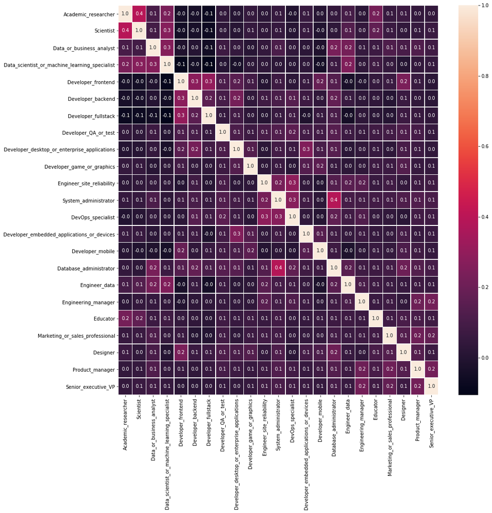

```python
ig, ax = plt.subplots(figsize=(15,15))         # Sample figsize in inches
#sns.heatmap(df1.iloc[:, 1:6:], annot=True, linewidths=.5, ax=ax)

sns.heatmap(df2020_DevType.corr(), annot=True, fmt=".1f", linewidths=.5);
```

We can confirm:

> Pairs that are highly correlated include

> `[database administrator]` and `[system administrator]` (**correlation 0.4**)

> `[DevOps specialist]` and `[site reliability engineer]` (**correlation 0.3**) ,

> `[academic researcher]` and `[scientist]` (**correlation 0.4**), and

> `[designer]` and `[front-end developer]` (**correaltion 0.2**).

We have verified our mapping results for **`df2020`** `DevType`. We have created new columns for each of the developer types provided in the questionnaire.

## Tidiness problem

> *Rule: Each variable forms a column*
> - (Q4) **`df2020`** column `MiscTechWorkedWith` contains a combination of all the technology types provided in the multiple choice question of the survey.

#### Define

- Create a list of all the different technologies provided in the multiple choice questionnaire of the survey.
- Create new columns in **`df2020`** of type boolean for each developer type listed in `MiscTechWorkedWith` .
- Replace white spaces and special characters in the column names to facilitate access via dot notation
- Create a new dataframe **`f2020_MiscTechWorkedWith`** that consists of the column `MiscTechWorkedWith` and the boolean variables mapped from **`df2020`** `MiscTechWorkedWith`.
- Delete NANs in **`f2020_MiscTechWorkedWith`**
- Delete **`df2020`** column `MiscTechWorkedWith`

```python
MiscTechWorkedWith = df2020_new.MiscTechWorkedWith.unique()

txt = []

for i in range(len(MiscTechWorkedWith)):
    name = (MiscTechWorkedWith[i].split(";"))
    txt.append(name)

MiscTechWorkedWith = set(list(chain.from_iterable(txt))) # The data type SET makes sure that
                                                         # every technology only appears once
len(MiscTechWorkedWith)
```

```
19
```

There are 19 different technologies to choose from in this question of the survey.

```python
# We add a semicolon at the end of every observation of the variable MiscTechWorkedWith to help us identifying
# the technologies correctly.

df2020_clean.MiscTechWorkedWith = df2020_clean.MiscTechWorkedWith + ";"
```

We want to create new columns for each of the technologies provided in the survey. The variables are of type boolean.

```python
def add_MiscTechWorkedWith(df):
    for name in MiscTechWorkedWith:
        df2020_clean[name] = False
        df2020_clean[name] = df2020_clean[df2020_clean['MiscTechWorkedWith'].str.contains(name + ';', na=False)]
        df2020_clean[name] = (df2020_clean[name] > 0)
        print(name)


add_MiscTechWorkedWith(df2020_clean)
```

```
React Native
TensorFlow
Ansible
Unreal Engine
Node.js
.NET Core
Puppet
Chef
Torch/PyTorch
Unity 3D
Flutter
Teraform
Keras
Hadoop
Cordova
Apache Spark
Xamarin
Pandas
.NET
```

Let us create a new dataframe **`df2020_MiscTechWorkedWith`** that consists of the column `MiscTechWorkedWith` and the 19 boolean variables mapped from `MiscTechWorkedWith`.

```python
df2020_MiscTechWorkedWith = df2020_clean.filter(["MiscTechWorkedWith", ".NET" , "Puppet" ,"Cordova" ,
                                      "Unreal Engine", "Node.js", "Pandas", "TensorFlow" ,
                                      "React Native" , "Torch/PyTorch" ,  "Chef" , "Hadoop" , "Flutter" ,
                                      "Apache Spark" , "Teraform", "Unity 3D" , "Keras" ,
                                      ".NET Core" , "Xamarin" , "Ansible" ], axis=1)
```

Now we drop all rows with NANs in column **`f2020_MiscTechWorkedWith`** `MiscTechWorkedWith` and keep the changes.

```python
df2020_MiscTechWorkedWith = df2020_MiscTechWorkedWith.dropna(subset=['MiscTechWorkedWith'], axis=0)
df2020_MiscTechWorkedWith.shape
```

```
(40314, 20)
```

```python
df2020_MiscTechWorkedWith.head()
```

|  | MiscTechWorkedWith | .NET | Puppet | Cordova | Unreal Engine | Node.js | Pandas | TensorFlow | React Native | Torch/PyTorch | Chef | Hadoop | Flutter | Apache Spark | Teraform | Unity 3D | Keras | .NET Core | Xamarin | Ansible |
| --- | --- | --- | --- | --- | --- | --- | --- | --- | --- | --- | --- | --- | --- | --- | --- | --- | --- | --- | --- | --- |
| 0 | .NET;.NET Core; | True | False | False | False | False | False | False | False | False | False | False | False | False | False | False | False | True | False | False |
| 1 | React Native; | False | False | False | False | False | False | False | True | False | False | False | False | False | False | False | False | False | False | False |
| 4 | Ansible; | False | False | False | False | False | False | False | False | False | False | False | False | False | False | False | False | False | False | True |
| 7 | Ansible; | False | False | False | False | False | False | False | False | False | False | False | False | False | False | False | False | False | False | True |
| 9 | Pandas; | False | False | False | False | False | True | False | False | False | False | False | False | False | False | False | False | False | False | False |

What is the share of recipients in the 2020 survey who provided an answer to the `MiscTechWorkedWith` question?

```python
MiscTechWorkedWith_nonNANs = df2020_clean.MiscTechWorkedWith.count() / df2020_clean.MiscTechWorkedWith.shape[0]
MiscTechWorkedWith_nonNANs
```

```
0.6254014055010007
```

We delete the **`df2020`** column `MiscTechWorkedWith`, because all of the information is now provided in the 19 new boolean variables (i.e. columns) for each of the technology types.

```python
df2020_clean = df2020_clean.drop(['MiscTechWorkedWith'], axis=1)
```

#### Test

```python
df2020_clean.dtypes.tail(19)
```

```
React Native     bool
TensorFlow       bool
Ansible          bool
Unreal Engine    bool
Node.js          bool
.NET Core        bool
Puppet           bool
Chef             bool
Torch/PyTorch    bool
Unity 3D         bool
Flutter          bool
Teraform         bool
Keras            bool
Hadoop           bool
Cordova          bool
Apache Spark     bool
Xamarin          bool
Pandas           bool
.NET             bool
dtype: object
```

We should be able to read the share of each technology.

```python
MiscTechWorkedWith_share = df2020_MiscTechWorkedWith.mean().tail(19).sort_values()
MiscTechWorkedWith_share
```

```
Chef             0.018182
Puppet           0.023441
Unreal Engine    0.032644
Hadoop           0.044600
Torch/PyTorch    0.046435
Apache Spark     0.051818
Xamarin          0.058466
Cordova          0.060004
Keras            0.062112
Teraform         0.062460
Flutter          0.071861
Ansible          0.073300
Unity 3D         0.109466
React Native     0.114749
TensorFlow       0.115394
Pandas           0.155107
.NET Core        0.266781
.NET             0.350846
Node.js          0.514486
dtype: float64
```

We verify our results by comparing them with Stackoverflow's analysis of *Other Frameworks, Libraries, and Tools* for all Respondants in the 2020 survey.

> https://insights.stackoverflow.com/survey/2020#most-popular-technologies

> `Similar to last year, we asked about many of the other miscellaneous technologies that developers are using. For the second year in a row, Node.js takes the top spot, as it is used by half of the respondents. We also see growth across the board in the popularity of data analysis and machine learning technologies such as Pandas, TensorFlow, and Torch/PyTorch.`

> 40,314 responses; select all that apply"

```python
df2020_MiscTechWorkedWith.count().head(1)
```

```
MiscTechWorkedWith    40314
dtype: int64
```

> We can verify that `[Node.js]` is the most popular technology used by 51.4 percent of respondants. The data analysis and machine learning technologies `[Pandas]`, `[TensorFlow]` , and `[Torch/PyTorch]` are used by 15.5 percent , 11.5 percent and 4.6 percent , respectively.

We have verified our mapping results for **`df2020`** `MiscTechWorkedWith`. We have created new columns for each of the technologies provided as an option in the questionnaire.

## Tidiness problem

> *Rule: Each variable forms a column*
> - (Q5) **`df2018`** and **`df2020`** columns `LanguageWorkedWith` and `LanguageDesireNextYear` contain a combination of all the programming languages that a developer uses or would like to learn/use next year.

#### Define

- Create a list of all the different languages provided in the multiple choice questionnaires of the two surveys.
- Create new columns in **`df2018`** and **`df2020`** of type boolean for each language listed in `LanguageWorkedWith` .

#### Code

```python
language2018 = df2018_clean.LanguageWorkedWith.dropna().unique()

txt = []

for i in range(len(language2018)):
    name = (language2018[i].split(";"))
    txt.append(name)

programming_language2018 = set(list(chain.from_iterable(txt)))
programming_language2018
```

```
{'Assembly',
 'Bash/Shell',
 'C',
 'C#',
 'C++',
 'CSS',
 'Clojure',
 'Cobol',
 'CoffeeScript',
 'Delphi/Object Pascal',
 'Erlang',
 'F#',
 'Go',
 'Groovy',
 'HTML',
 'Hack',
 'Haskell',
 'Java',
 'JavaScript',
 'Julia',
 'Kotlin',
 'Lua',
 'Matlab',
 'Objective-C',
 'Ocaml',
 'PHP',
 'Perl',
 'Python',
 'R',
 'Ruby',
 'Rust',
 'SQL',
 'Scala',
 'Swift',
 'TypeScript',
 'VB.NET',
 'VBA',
 'Visual Basic 6'}
```

```python
len(programming_language2018)
```

```
38
```

In **`df2018`** there are 38 programming languages.

Let us see how many programming languages were used in **`df2020`** .

```python
language2020 = df2020_clean.LanguageWorkedWith.dropna().unique()


txt = []

for i in range(len(language2020)):
    name = (language2020[i].split(";"))
    txt.append(name)

programming_language2020 = set(list(chain.from_iterable(txt)))
programming_language2020
```

```
{'Assembly',
 'Bash/Shell/PowerShell',
 'C',
 'C#',
 'C++',
 'Dart',
 'Go',
 'HTML/CSS',
 'Haskell',
 'Java',
 'JavaScript',
 'Julia',
 'Kotlin',
 'Objective-C',
 'PHP',
 'Perl',
 'Python',
 'R',
 'Ruby',
 'Rust',
 'SQL',
 'Scala',
 'Swift',
 'TypeScript',
 'VBA'}
```

```python
len(programming_language2020)
```

```
25
```

In **`df2020`** there are only 25 programming languages. In contrast to the 2018 survey, the two programming languages `[HTML]` and `[CSS]` have been combined to `[HTML/CSS]` and `[Bash/Shell]` has been expanded to `[Bash/Shell/PowerShell]`.

```python
programming_language_difference = programming_language2020.difference(programming_language2018)
programming_language_difference
```

```
{'Bash/Shell/PowerShell', 'Dart', 'HTML/CSS'}
```

We will be using these lists of programming languages.

```python
programming_language2018 = ['Assembly;', 'Bash/Shell;', 'C;', 'C#;', 'C++;', 'CSS;', 'Clojure;', 'Cobol;', 'CoffeeScript;',
                            'Delphi/Object Pascal;', 'Erlang;', 'F#;', 'Go;', 'Groovy;', 'HTML;', 'Hack;', 'Haskell;',
                            'Java;', 'JavaScript;', 'Julia;', 'Kotlin;', 'Lua;', 'Matlab;', 'Objective-C;', 'Ocaml;',
                            'PHP;', 'Perl;', 'Python;', 'R;', 'Ruby;', 'Rust;', 'SQL;', 'Scala;', 'Swift;', 'TypeScript;',
                            'VB.NET;', 'VBA;', 'Visual Basic 6;']



programming_language2020 = ["Assembly;", "Bash/Shell/PowerShell;", "C;", "C#;", "C++;",
                 "Dart;", "Go;","HTML/CSS;", "Haskell;", "Java;",
                 "JavaScript;", "Julia;", "Kotlin;", "Objective-C;","PHP;",
                 "Perl;","Python;", "R;", "Ruby;", "Rust;",
                 "SQL;","Scala;", "Swift;", "TypeScript;", "VBA;"]


# We add a semicolon at the end of every observation of the variables LanguageWorkedWith and LanguageDesireNextYear
# to help us identifying the programming languages correctly.

df2018_clean.LanguageDesireNextYear = df2018_clean.LanguageDesireNextYear + ";"
df2018_clean.LanguageWorkedWith     = df2018_clean.LanguageWorkedWith + ";"
df2020_clean.LanguageDesireNextYear = df2020_clean.LanguageDesireNextYear + ";"
df2020_clean.LanguageWorkedWith     = df2020_clean.LanguageWorkedWith + ";"
```

We want to create new columns for each of the 38 programming languages provided in **`df2018`** `LanguageWorkedWith` . The variables are of type boolean.

```python
# time efficient methode to map the column into boolean variables
for name in programming_language2018:
    df2018_clean[name] = False  # assign a new column with boolean value False by default
    df2018_clean[name] = df2018_clean[df2018_clean['LanguageWorkedWith'].str.contains (name, na=False, regex = False)]
    df2018_clean[name] = (df2018_clean[name] > 0)
    print(name)

# We need to correct the doubble counting of "C;" and "Objective-C;"

df2018_clean['Language'] = df2018_clean['LanguageWorkedWith'].str.replace(r'Objective-C;', '')
df2018_clean['C;']       =  False
df2018_clean['C;']       =  df2018_clean[df2018_clean['Language'].str.contains ('C;', na=False, regex = False)]
df2018_clean['C;']       = (df2018_clean['C;'] > 0)
df2018_clean             = df2018_clean.drop(['Language'], axis=1)
```

```
Assembly;
Bash/Shell;
C;
C#;
C++;
CSS;
Clojure;
Cobol;
CoffeeScript;
Delphi/Object Pascal;
Erlang;
F#;
Go;
Groovy;
HTML;
Hack;
Haskell;
Java;
JavaScript;
Julia;
Kotlin;
Lua;
Matlab;
Objective-C;
Ocaml;
PHP;
Perl;
Python;
R;
Ruby;
Rust;
SQL;
Scala;
Swift;
TypeScript;
VB.NET;
VBA;
Visual Basic 6;
```

We want to create new columns for each of the 25 programming languages provided in **`df2020`** `LanguageWorkedWith` . The variables are of type boolean.

```python
for name in programming_language2020:
    df2020_clean[name] = False
    df2020_clean[name] = df2020_clean[df2020_clean['LanguageWorkedWith'].str.contains (name, na=False, regex = False)]
    df2020_clean[name] = (df2020_clean[name] > 0)
    print(name)


# df2020_clean['C;'] =   (df2020_clean['C;']) & (~df2020_clean['Objective-C;'])

df2020_clean['Language'] = df2020_clean['LanguageWorkedWith'].str.replace(r'Objective-C;', '')
df2020_clean['C;']       =  False
df2020_clean['C;']       =  df2020_clean[df2020_clean['Language'].str.contains ('C;', na=False, regex = False)]
df2020_clean['C;']       = (df2020_clean['C;'] > 0)
df2020_clean             = df2020_clean.drop(['Language'], axis=1)
```

```
Assembly;
Bash/Shell/PowerShell;
C;
C#;
C++;
Dart;
Go;
HTML/CSS;
Haskell;
Java;
JavaScript;
Julia;
Kotlin;
Objective-C;
PHP;
Perl;
Python;
R;
Ruby;
Rust;
SQL;
Scala;
Swift;
TypeScript;
VBA;
```

We will be using the dataframe **`df2018_LanguageWorkedWith`** that consists of the column `LanguageWorkedWith` and the 38 boolean variables mapped from **`df2018`** `LanguageWorkedWith`.

```python
df2018_LanguageWorkedWith = df2018_clean.filter(['LanguageWorkedWith', 'Assembly;', 'Bash/Shell;',
                                                 'C;', 'C#;', 'C++;', 'CSS;', 'Clojure;', 'Cobol;', 'CoffeeScript;',
                                                 'Delphi/Object Pascal;', 'Erlang;', 'F#;','Go;', 'Groovy;',
                                                 'HTML;', 'Hack;', 'Haskell;', 'Java;', 'JavaScript;', 'Julia;',
                                                 'Kotlin;', 'Lua;', 'Matlab;', 'Objective-C;', 'Ocaml;',
                                                 'PHP;', 'Perl;', 'Python;', 'R;', 'Ruby;', 'Rust;',
                                                 'SQL;', 'Scala;', 'Swift;', 'TypeScript;',
                                                 'VB.NET;', 'VBA;', 'Visual Basic 6;'], axis=1)
```

Now we drop all rows with NANs in column **`f2018_LanguageWorkedWith`** `LanguageWorkedWith` and keep the changes.

```python
df2018_LanguageWorkedWith = df2018_LanguageWorkedWith.dropna(subset=['LanguageWorkedWith'], axis=0)
df2018_LanguageWorkedWith.shape
```

```
(78334, 39)
```

What is the share of recipients in **`df2018`** who provided an answer to the `LanguageWorkedWith` question?

```python
LanguageWorkedWith_nonNANs2018 = df2018_clean.LanguageWorkedWith.count() / df2018_clean.LanguageWorkedWith.shape[0]
LanguageWorkedWith_nonNANs2018
```

```
0.7924131303424207
```

We will be using the dataframe **`df2020_LanguageWorkedWith`** that consists of the column `LanguageWorkedWith` and the 25 boolean variables mapped from **`df2020`** `LanguageWorkedWith`.

```python
df2020_LanguageWorkedWith = df2020_clean.filter(['LanguageWorkedWith', "Assembly;", "Bash/Shell/PowerShell;",
                                                 "C;", "C#;", "C++;", "Dart;", "Go;", "HTML/CSS;", "Haskell;",
                                                 "Java;", "JavaScript;", "Julia;", "Kotlin;", "Objective-C;",
                                                 "PHP;", "Perl;","Python;",
                                                 "R;", "Ruby;", "Rust;",
                                                 "SQL;","Scala;", "Swift;",
                                                 "TypeScript;", "VBA;"], axis=1)
```

Now we drop all rows with NANs in column **`df2020_LanguageWorkedWith`** `LanguageWorkedWith` and keep the changes.

```python
df2020_LanguageWorkedWith = df2020_LanguageWorkedWith.dropna(subset=['LanguageWorkedWith'], axis=0)
df2020_LanguageWorkedWith.shape
```

```
(57378, 26)
```

What is the share of recipients in **`df2020`** who provided an answer to the `LanguageWorkedWith` question?

```python
LanguageWorkedWith_nonNANs = df2020_clean.LanguageWorkedWith.count() / df2020_clean.LanguageWorkedWith.shape[0]
LanguageWorkedWith_nonNANs
```

```
0.8901196072043561
```

#### Test

```python
df2018_clean.dtypes.tail(38)
```

```
Assembly;                bool
Bash/Shell;              bool
C;                       bool
C#;                      bool
C++;                     bool
CSS;                     bool
Clojure;                 bool
Cobol;                   bool
CoffeeScript;            bool
Delphi/Object Pascal;    bool
Erlang;                  bool
F#;                      bool
Go;                      bool
Groovy;                  bool
HTML;                    bool
Hack;                    bool
Haskell;                 bool
Java;                    bool
JavaScript;              bool
Julia;                   bool
Kotlin;                  bool
Lua;                     bool
Matlab;                  bool
Objective-C;             bool
Ocaml;                   bool
PHP;                     bool
Perl;                    bool
Python;                  bool
R;                       bool
Ruby;                    bool
Rust;                    bool
SQL;                     bool
Scala;                   bool
Swift;                   bool
TypeScript;              bool
VB.NET;                  bool
VBA;                     bool
Visual Basic 6;          bool
dtype: object
```

```python
df2020_clean.dtypes.tail(25)
```

```
Assembly;                 bool
Bash/Shell/PowerShell;    bool
C;                        bool
C#;                       bool
C++;                      bool
Dart;                     bool
Go;                       bool
HTML/CSS;                 bool
Haskell;                  bool
Java;                     bool
JavaScript;               bool
Julia;                    bool
Kotlin;                   bool
Objective-C;              bool
PHP;                      bool
Perl;                     bool
Python;                   bool
R;                        bool
Ruby;                     bool
Rust;                     bool
SQL;                      bool
Scala;                    bool
Swift;                    bool
TypeScript;               bool
VBA;                      bool
dtype: object
```

We should be able to read the share of each language worked with in 2018.

```python
df2018_LanguageWorkedWith_share = df2018_LanguageWorkedWith.mean().tail(38).sort_values()
df2018_LanguageWorkedWith_share
```

```
Hack;                    0.003243
Julia;                   0.005489
Ocaml;                   0.006000
Cobol;                   0.007532
Erlang;                  0.011311
Clojure;                 0.013174
F#;                      0.014234
Rust;                    0.023706
Haskell;                 0.025034
Delphi/Object Pascal;    0.025851
CoffeeScript;            0.033230
Lua;                     0.034889
Visual Basic 6;          0.039408
Perl;                    0.041872
Groovy;                  0.043059
Scala;                   0.043659
Kotlin;                  0.044783
VBA;                     0.048638
Matlab;                  0.058263
R;                       0.061442
VB.NET;                  0.067072
Objective-C;             0.070340
Go;                      0.070621
Assembly;                0.073531
Swift;                   0.080553
Ruby;                    0.100991
TypeScript;              0.173947
C;                       0.230321
C++;                     0.253683
PHP;                     0.307287
C#;                      0.344091
Python;                  0.387558
Bash/Shell;              0.397937
Java;                    0.453456
SQL;                     0.570250
CSS;                     0.650790
HTML;                    0.684607
JavaScript;              0.698113
dtype: float64
```

We verify our results by comparing them with Stackoverflow's 2018 analysis of *Programming, Scripting, and Markup Languages* for all Respondants.

> https://insights.stackoverflow.com/survey/2018#technology-_-programming-scripting-and-markup-languages

> `For the sixth year in a row, JavaScript is the most commonly used programming language. Python has risen in the ranks, surpassing C# this year, much like it surpassed PHP last year. Python has a solid claim to being the fastest-growing major programming languag.`

> `We see close alignment in the technology choices of professional developers and the developer population overall.`

78,334 responses; select all that apply

```python
df2018_LanguageWorkedWith.shape[0]
```

```
78334
```

> We can confirm that in the 2018 survey, `[JavaScript]` is the most popular language, used by 70 percent of respondants. We can confirm that `[Python]` (38.8 percent) has surpassed both `[C#]` (34.4 percent) and `[PHP]` (30.7 percent) .

We have verified our results for the mapping of **`df2018`** `LanguageWorkedWith`.

We should be able to read the share of each language worked with in 2020.

```python
df2020_LanguageWorkedWith_share = df2020_LanguageWorkedWith.mean().tail(25).sort_values()
df2020_LanguageWorkedWith_share
```

```
Julia;                    0.009045
Haskell;                  0.021297
Perl;                     0.031301
Scala;                    0.035763
Dart;                     0.039736
Objective-C;              0.040782
Rust;                     0.051047
R;                        0.057304
Swift;                    0.059204
VBA;                      0.060982
Assembly;                 0.061923
Ruby;                     0.070515
Kotlin;                   0.077870
Go;                       0.087804
C;                        0.217627
C++;                      0.238889
TypeScript;               0.254070
PHP;                      0.261546
C#;                       0.314424
Bash/Shell/PowerShell;    0.330789
Java;                     0.402140
Python;                   0.440709
SQL;                      0.547475
HTML/CSS;                 0.630573
JavaScript;               0.676601
dtype: float64
```

We verify our results by comparing them with Stackoverflow's analysis of *Programming, Scripting, and Markup Languages* for all Respondants.

> https://insights.stackoverflow.com/survey/2020#most-popular-technologies

> `Unsurprisingly, for the eighth year in a row, JavaScript has maintained it's stronghold as the most commonly used programming language. Going further down the list, we also see moderate gains for TypeScript, edging out C in terms of popularity. Additionally, Ruby, once in the top 10 of this list as recently as 2017, has declined, being surpassed by newer, trendier technologies such as Go and Kotlin.`

> 57,378 responses; select all that apply"

```python
df2020_clean.LanguageWorkedWith.count()
```

```
57378
```

> We can confirm that in the 2020 survey `[JavaScript]` is the most popular programming language used by 67.7 percent of respondants.

We have verified our results for the mapping of **`df2020`** `LanguageWorkedWith`.

# II. What is the structure of the 2020 dataset?

The Developer Survey 2020 contains 61 questions (i.e. columns) and we have added boolean variables for developer type `DevType`, language currently worked with `LanguageWorkedWith` and miscellaneous technology currently worked with `MiscTechWorkedWith`.

</font> **Identifiers and Keys**:

> **Respondent**: Randomized respondent ID number (not in order of survey response time)

</font> **64461 unique entries**:

</font> **Numeric Variables**: (Integer) or (Float)

> **Age**: What is your age (in years)?

> **Age1stCode**: At what age did you write your first line of code or program? (e.g., webpage, Hello World, Scratch project)

> **CompTotal**: What is your current total compensation (salary, bonuses, and perks, before taxes and deductions), in `CurrencySymbol`? Please enter a whole number in the box below, without any punctuation. If you are paid hourly, please estimate an equivalent weekly, monthly, or yearly salary. If you prefer not to answer, please leave the box empty.

> **ConvertedComp** Salary converted to annual USD salaries using the exchange rate on 2020-02-19, assuming 12 working months and 50 working weeks.

> **WorkWeekHrs**: On average, how many hours per week do you work? Please enter a whole number in the box.

> **YearsCode** : Including any education, how many years have you been coding in total?

> **YearsCodePro**: NOT including education, how many years have you coded professionally (as a part of your work)?

</font> **Categorical variables with only one option to choose from** ***(choose one)***

> **CompFreq** Is that compensation weekly, monthly, or yearly?

> **Country** Where do you live?

> > *180 countries and dependent territories* to choose from

> **CurrencyDesc** Which currency do you use day-to-day? If your answer is complicated, please pick the one you're most comfortable estimating in.

> **CurrencySymbol** Which currency do you use day-to-day? If your answer is complicated, please pick the one you're most comfortable estimating in.

> **EdLevel** Which of the following best describes the highest level of formal education that you have completed?

> > *Associate degree (A.A., A.S., etc.)* , *Bachelor’s degree (B.A., B.S., B.Eng., etc.* , *I never completed any formal education* , *Master’s degree (M.A., M.S., M.Eng., MBA, etc.)* *Other doctoral degree (Ph.D., Ed.D., etc.* *Primary/elementary school* *Professional degree (JD, MD, etc.)* *Secondary school (e.g. American high school, German Realschule or Gymnasium, etc.)* *Some college/university study without earning a degree*

> **Employment** Which of the following best describes your current employment status?

> > *Employed full-time*  
> > *Employed part-time*  
> > *Independent contractor, freelancer, or self-employed* *Not employed, and not looking for work* *Not employed, but looking for work*  
> > *Retired* *Student*

> **Hobbyist** Do you code as a hobby?

> > **Yes**  
> > *No*

> **JobSat** How satisfied are you with your current job? (If you work multiple jobs, answer for the one you spend the most hours on.)

> > *Neither satisfied nor dissatisfied* *Slightly dissatisfied* *Slightly satisfied* *Very dissatisfied* *Very satisfied*

> **JobSeek** Which of the following best describes your current job-seeking status?

> > *I am actively looking for a job* *I am not interested in new job opportunities* *I’m not actively looking, but I am open to new opportunities* *I’m not actively looking, but I am open to new opportunities*

> **NEWDevOps**: Does your company have a dedicated DevOps person?

> > **No** *Not sure* **Yes**

> **NEWDevOpsImpt**: How important is the practice of DevOps to scaling software development?

> > *Extremely important* *Neutral* *Not at all important*  
> > *Not very important* *Somewhat important*

> **NEWEdImpt**: How important is a formal education, such as a university degree in computer science, to your career?

> > *Critically important* *Fairly important*  
> > *Not at all important/not necessary* *Somewhat important* *Very important*

> **NEWLearn**: How frequently do you learn a new language or framework?

> > *Every few months* *Once a decade* *Once a year* *Once every few years*

> **NEWOffTopic**: Do you think Stack Overflow should relax restrictions on what is considered “off-topic”?

> > *No* *Not sure* *Yes*

> **NEWOnboardGood** Do you think your company has a good onboarding process? (By onboarding, we mean the structured process of getting you settled in to your new role at a company)

> > *No* *Onboarding? What onboarding?* *Yes*

> **NEWOtherComms** Are you a member of any other online developer communities?

> > **Yes** , *No*

> **NEWOvertime** How often do you work overtime or beyond the formal time expectation of your job?

> > *Never*  
> > *Occasionally: 1-2 days per quarter but less than monthly*  
> > *Often: 1-2 days per week or more*  
> > *Rarely: 1-2 days per year or less*  
> > *Sometimes: 1-2 days per month but less than weekly*

> **NEWPurpleLink** You search for a coding solution online and the first result link is purple because you already visited it. How do you feel?

> > *Hello, old friend*  
> > *Indifferent*  
> > *Amused*  
> > *Annoyed*

> **MainBranch** Which of the following options best describes you today? Here, by "developer" we mean "someone who writes code."

> > *I am a developer by profession* , *I am a student who is learning to code* , *I am not primarily a developer, but I write code sometimes as part of my work* , *I code primarily as a hobby* , *I used to be a developer by profession, but no longer am* ,

> **OpSys** What is the primary operating system in which you work?

> > *Berkeley Software Distribution (BSD)* *Linux-based* *MacOS* *Windows*

> **OrgSize** Approximately how many people are employed by the company or organization you currently work for?

> > *10,000 or more employees* *5,000 to 9,999 employees* *1,000 to 4,999 employees* *500 to 999 employees* *100 to 499 employees* *20 to 99 employees* *10 to 19 employees* *2 to 9 employees* *Just me - I am a freelancer, sole proprietor, etc.*

> **PurchaseWhat** What level of influence do you, personally, have over new technology purchases at your organization?

> > *I have little or no influence* *I have some influence* *I have a great deal of influence*

> **SOAccount** Do you have a Stack Overflow account?

> > *Yes*  
> > *No*  
> > *Not sure/can't remember*

> **SOComm** Do you consider yourself a member of the Stack Overflow community?

> > *Yes, somewhat*  
> > *No, not really*  
> > *Neutral*  
> > *Yes, definitely*  
> > *No, not at all*  
> > *Not sure*

> **SOPartFreq** How frequently would you say you participate in Q&A on Stack Overflow? By participate we mean ask, answer, vote for, or comment on questions.

> > *Less than once per month or monthly*  
> > *I have never participated in Q&A on Stack Overflow*  
> > *A few times per month or weekly*  
> > *A few times per week*  
> > *Daily or almost daily*  
> > *Multiple times per day*

> **SOVisitFreq** How frequently would you say you visit Stack Overflow?

> > *Less than once per month or monthly*  
> > *I have never participated in Q&A on Stack Overflow*  
> > *A few times per month or weekly*  
> > *A few times per week*  
> > *Daily or almost daily*  
> > *Multiple times per day*

> **SurveyEase** How easy or difficult was this survey to complete?

> > *Easy*  
> > *Neither easy nor difficult*  
> > *Difficult*

> **SurveyLength** How do you feel about the length of the survey this year?

> > *Appropriate in length*  
> > *Too long*  
> > *Too short*

> **Trans** Are you transgender?

> > *No*  
> > *Yes*

> **UndergradMajor** What was your primary field of study?

> > *Computer science, computer engineering, or software engineering*  
> > *Another engineering discipline (such as civil, electrical, mechanical, etc.)*  
> > *Information systems, information technology, or system administration*  
> > *A natural science (such as biology, chemistry, physics, etc.)*  
> > *Mathematics or statistics*  
> > *Web development or web design*  
> > *A business discipline (such as accounting, finance, marketing, etc.)*  
> > *A humanities discipline (such as literature, history, philosophy, etc.)*  
> > *A social science (such as anthropology, psychology, political science, etc.)*  
> > *Fine arts or performing arts (such as graphic design, music, studio art, etc.)*  
> > *I never declared a major*  
> > *A health science (such as nursing, pharmacy, radiology, etc.)*

> **WelcomeChange** Compared to last year, how welcome do you feel on Stack Overflow?

> > *Just as welcome now as I felt last year*  
> > *Somewhat more welcome now than last year*  
> > *A lot more welcome now than last year*  
> > *Somewhat less welcome now than last year*  
> > *A lot less welcome now than last year*  
> > *Not applicable - I did not use Stack Overflow last year*

</font> **Categorical variables with multiple options to choose** ***(select all that apply)***

> </font>We will be ignoring most of this variables in further analysis because of the large number of unique entries!

</font> From this list we will only be using **``DevType`` , ``LanguageDesireNextYear`` , ``LanguageWorkedWith``** and ``MiscTechWorkedWith`` going forward

`DatabaseDesireNextYear` </font> **(3193 unique entries)**:

> Which database environments have you done extensive development work in over the past year, and which do you want to work in over the next year? (If you both worked with the database and want to continue to do so, please check both boxes in that row.)

`DatabaseWorkedWith` </font> **(2808 unique entries)**:

> Which database environments have you done extensive development work in over the past year, and which do you want to work in over the next year? (If you both worked with the database and want to continue to do so, please check both boxes in that row.)

**DevType** (</font> **(8269 unique entries)**:

> Which of the following describe you? Please select all that apply. *We have created Boolean variables (i.e. new columns) for each choice (see below)*

`Ethnicity` </font> **(208 unique entries)**:

> Which of the following describe you, if any? Please check all that apply. If you prefer not to answer, you may leave this question blank.

`Gender` (</font> **(7 unique entries)**:

> Which of the following describe you, if any? Please check all that apply. If you prefer not to answer, you may leave this question blank.

`JobFactors` (</font> **(230 unique entries)**:

> Imagine that you are deciding between two job offers with the same compensation, benefits, and location. Of the following factors, which 3 are MOST important to you?

**LanguageDesireNextYear** (</font> **(16243 unique entries)**:

> Which programming, scripting, and markup languages have you done extensive development work in over the past year, and which do you want to work in over the next year? (If you both worked with the language and want to continue to do so, please check both boxes in that row.)

**LanguageWorkedWith** (</font> **(14256 unique entries)**:

> Which programming, scripting, and markup languages have you done extensive development work in over the past year, and which do you want to work in over the next year? (If you both worked with the language and want to continue to do so, please check both boxes in that row.) *We have created Boolean variables (i.e. new columns) for each choice (see below)*

`NEWCollabToolsDesireNextYear` (</font> **(1277 unique entries)**:

> Which collaboration tools have you done extensive development work in over the past year, and which do you want to work in over the next year? (If you worked with the tool and want to continue to do so, please check both boxes in that row.)

`NEWCollabToolsWorkedWith` (</font> **(1153 unique entries)**:

> Which collaboration tools have you done extensive development work in over the past year, and which do you want to work in over the next year? (If you worked with the tool and want to continue to do so, please check both boxes in that row.)

> In general, what drives you to look for a new job? Select all that apply.

`NEWJobHuntResearch` (</font> **(63 unique entries)**:

> When job searching, how do you learn more about a company? Select all that apply.

`NEWPurchaseResearch` (</font> **(63 unique entries)**:

> When buying a new tool or software, how do you discover and research available solutions? Select all that apply.

`NEWSOSites` (</font> **(61 unique entries)**:

> Which of the following Stack Overflow sites have you visited? Select all that apply.

`NEWStuck` (</font> **(444 unique entries)**:

> What do you do when you get stuck on a problem? Select all that apply.

`MiscTechDesireNextYear` (</font> **(5216 unique entries)**:

> Which other frameworks, libraries, and tools have you done extensive development work in over the past year, and which do you want to work in over the next year? (If you both worked with the framework and want to continue to do so, please check both boxes in that row.)

**MiscTechWorkedWith** (</font> **(2730 unique entries)**:

> Which other frameworks, libraries, and tools have you done extensive development work in over the past year, and which do you want to work in over the next year? (If you both worked with the framework and want to continue to do so, please check both boxes in that row.) *We have created Boolean variables (i.e. new columns) for each choice (see below)*

`PlatformDesireNextYear` (</font> **(7471 unique entries)**:

> Which platforms have you done extensive development work in over the past year, and which do you want to work in over the next year? (If you both worked with the platform and want to continue to do so, please check both boxes in that row.)

`PlatformWorkedWith` (</font> **(6287 unique entries)**:

> Which platforms have you done extensive development work in over the past year, and which do you want to work in over the next year? (If you both worked with the platform and want to continue to do so, please check both boxes in that row.)

`Sexuality` (</font> **(14 unique entries)**:

> Which of the following describe you, if any? Please check all that apply. If you prefer not to answer, you may leave this question blank.

`WebframeDesireNextYear` (</font> **(3986 unique entries)**:

> Which web frameworks have you done extensive development work in over the past year, and which do you want to work in over the next year? (If you both worked with the framework and want to continue to do so, please check both boxes in that row.)

`WebframeWorkedWith` (</font> **(3789 unique entries)**:

> Which web frameworks have you done extensive development work in over the past year, and which do you want to work in over the next year? (If you both worked with the framework and want to continue to do so, please check both boxes in that row.)

> </font> **Boolean variables**

> </font> (mapped from **DevType**)  
> **System_administrator** , *Developer_embedded_applications_or_devices* , **Marketing_or_sales_professional** , *Data_or_business_analyst* , **Academic_researcher** , *Developer_backend* , **Scientist** , *Engineer_data* , **Developer_frontend** , *Data_scientist_or_machine_learning_specialist* , **Engineering_manager** , *Developer_desktop_or_enterprise_applications* , **Developer_game_or_graphics** , *Designer* , **DevOps_specialist** , **Developer_mobile** , *Engineer_site_reliability* , **Developer_QA_or_test** , *Senior_executive_VP* , **Database_administrator** , *Educator* , **Product_manager** , **Developer_fullstack**

> </font> (mapped from **LanguageWorkedWith**)  
> **Assembly;** , *Bash/Shell/PowerShell;* , **C;** , *C#;* , **C++;** , *Dart;* , **Go;** , *HTML/CSS;* , **Haskell;** , *Java;* , **JavaScript;** , *Julia;* , **Kotlin;** , *Objective-C;* , **PHP;** , *Perl;* , **Python;** , *R;* , **Ruby;** , *Rust;* , **SQL;** , *Scala;* , **Swift;** , *TypeScript;* , **VBA;** (mapped from **MiscTechWorkedWith**)  
> **Node.js** , *Ansible* , **Cordova** , *Pandas* , **Flutter** , *Apache Spark* , **React Native** , *Torch/PyTorch* , **Keras** , *Unity 3D* , **Xamarin** , *.NET Core* , **.NET** , *Teraform* , **TensorFlow** , *Puppet* , **Chef** , *Hadoop* , **Unreal Engine**

# III. Exploration of numerical variables

Let us start the exploration process by looking at the distribution of the numerical variables in the surveys.

We will be using **Box-and-Whisker Plots**. A Box and Whisker Plot (or Box Plot) is a convenient way of visually displaying the data distribution through their quartiles. The lines extending parallel from the boxes are known as the “whiskers”, which are used to indicate variability outside the upper and lower quartiles.

## **Age** (Definition) </font>**2020 survey**

> What is your age (in years)? If you prefer not to answer, you may leave this question blank.

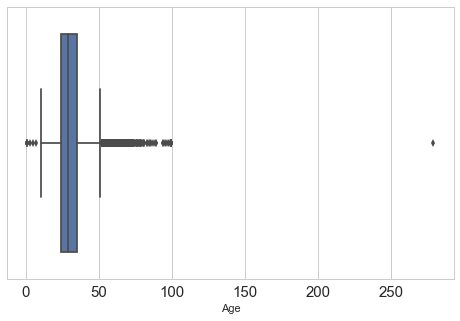

```
count    45446.000000
mean        30.834111
std          9.585392
min          1.000000
25%         24.000000
50%         29.000000
75%         35.000000
max        279.000000
Name: Age, dtype: float64
```

```python
sns.set(context='notebook', style='whitegrid', palette='deep', font='sans-serif', font_scale=1, rc=None)
plt.figure(figsize=[8, 5])
sns.boxplot(df2020_clean['Age'])
plt.xticks(rotation=0, fontsize=15)
plt.yticks(rotation=0, fontsize=15)
plt.show()
print(df2020_clean.Age.describe());
```

The first step in constructing a **box-and-whisker plot** is to first find the median (Q2),the lower quartile (Q1)and the upper quartile (Q3) of a given set of data.

### The median age of the respondants in the 2020 survey is 29 and the average age is 31 years.

> The lower quartile is 24 years and the upper quartile is 35 years. The middle half of a data set falls within the interquartile range. In a boxplot, the **interquartile range (IQR)** is represented by the width of the box (Q3 minus Q1).  
> </font>

```python
df2020_clean[df2020_clean['Age'] > 100]
```

|  | Respondent | MainBranch | Hobbyist | Age | Age1stCode | CompFreq | CompTotal | ConvertedComp | Country | CurrencyDesc | ... | Perl; | Python; | R; | Ruby; | Rust; | SQL; | Scala; | Swift; | TypeScript; | VBA; |
| --- | --- | --- | --- | --- | --- | --- | --- | --- | --- | --- | --- | --- | --- | --- | --- | --- | --- | --- | --- | --- | --- |
| 14375 | 14419 | I am a developer by profession | Yes | 279.0 | 16.0 | Yearly | 49000.0 | 52968.0 | Netherlands | European Euro | ... | False | False | False | False | False | False | False | False | False | False |

1 rows × 126 columns

Apparently, a dutch developer claims to be born around 1740 AD (Age 279) and to started coding around 1756 AD (Beginning of Seven Years' War in Europe). Nevertheless, the **whiskers** of the boxplot (i.e. the vertical lines extending to the most extreme, non-outlier data points) show that only a small fraction of respondants are over the age of 50. **A small number of outliers do not distort the major takeaway from this variable.**

## **Age1stCode** (Definition) </font>**2020 survey**

> At what age did you write your first line of code or program? (e.g., webpage, Hello World, Scratch project)

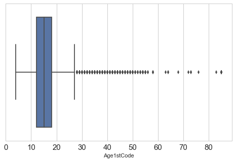

```
count    57900.000000
mean        15.410121
std          5.289951
min          4.000000
25%         12.000000
50%         15.000000
75%         18.000000
max         85.000000
Name: Age1stCode, dtype: float64
```

```python
sns.set(context='notebook', style='whitegrid', palette='deep', font='sans-serif', font_scale=1, rc=None)
plt.figure(figsize=[8, 5])
sns.boxplot(df2020_clean['Age1stCode'])
plt.xticks(rotation=0, fontsize=15)
plt.yticks(rotation=0, fontsize=15)
plt.show()
print(df2020_clean.Age1stCode.describe());
```

### </font>Most developers started coding in their teens.

## **YearsCode** (Definition) </font>**2020 survey**

> Including any education, how many years have you been coding in total?

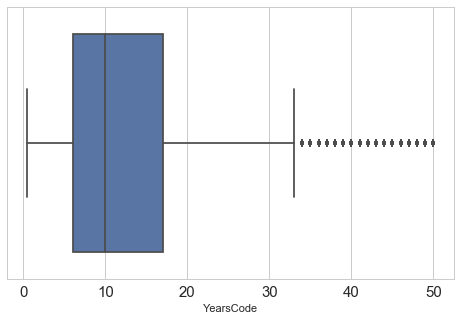

```
count    57684.000000
mean        12.713135
std          9.699281
min          0.500000
25%          6.000000
50%         10.000000
75%         17.000000
max         50.000000
Name: YearsCode, dtype: float64
```

```python
sns.set(context='notebook', style='whitegrid', palette='deep', font='sans-serif', font_scale=1, rc=None)
plt.figure(figsize=[8, 5])
sns.boxplot(df2020_clean['YearsCode'])
plt.xticks(rotation=0, fontsize=15)
plt.yticks(rotation=0, fontsize=15)
plt.show()
print(df2020_clean.YearsCode.describe());
```

### The median coding experiance of the respondants in the 2020 survey is 10 years.

> The Interquartile range (IQR) is 6 to 17 years.  
> </font>

## **YearsCodePro** (Definition) </font>**2020 survey**

> NOT including education, how many years have you coded professionally (as a part of your work)?

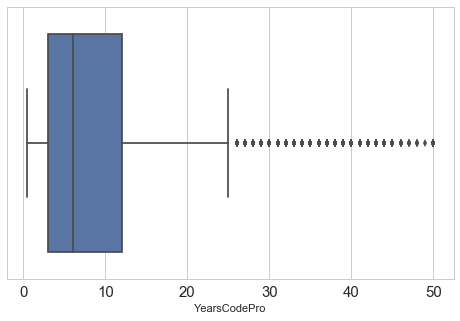

```
count    46349.000000
mean         8.514358
std          7.875942
min          0.500000
25%          3.000000
50%          6.000000
75%         12.000000
max         50.000000
Name: YearsCodePro, dtype: float64
```

```python
sns.set(context='notebook', style='whitegrid', palette='deep', font='sans-serif', font_scale=1, rc=None)
plt.figure(figsize=[8, 5])
sns.boxplot(df2020_clean['YearsCodePro'])
plt.xticks(rotation=0, fontsize=15)
plt.yticks(rotation=0, fontsize=15)
plt.show()
print(df2020_clean.YearsCodePro.describe());
```

### Respondants in the 2020 survey have a median professional coding experiance of 6 years.

> Interquartile range (IQR) is between 3 to 12 years. Very few developers have been coding professionally for more than 25 years.  
> </font>

## WorkWeekHrs (Definition) </font>**2020 survey**

> On average, how many hours per week do you work? Please enter a whole number in the box.

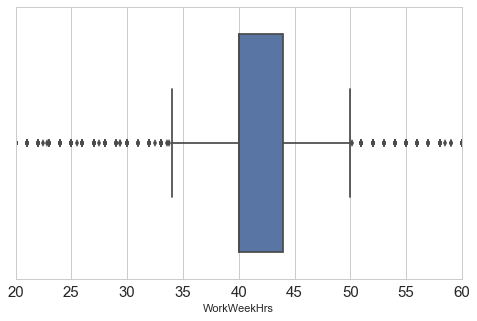

```
count    41151.000000
mean        40.782174
std         17.816383
min          1.000000
25%         40.000000
50%         40.000000
75%         44.000000
max        475.000000
Name: WorkWeekHrs, dtype: float64
```

```python
sns.set(context='notebook', style='whitegrid', palette='deep', font='sans-serif', font_scale=1, rc=None)
plt.figure(figsize=[8, 5])
sns.boxplot(df2020_clean['WorkWeekHrs'])
plt.xticks(rotation=0, fontsize=15)
plt.yticks(rotation=0, fontsize=15)
plt.xlim([20, 60])
plt.show()
print(df2020_clean.WorkWeekHrs.describe());
```

### The median respondants in the 2020 survey works 40 hours a week.

# Distribution of Salaries

> What is the distribution of salaries in local currency and converted into USD?

## **CompTotal** (Definition) </font>**2020 survey**

> What is your current total compensation (salary, bonuses, and perks, before taxes and deductions), in CurrencySymbol? Please enter a whole number in the box below, without any punctuation. If you are paid hourly, please estimate an equivalent weekly, monthly, or yearly salary. If you prefer not to answer, please leave the box empty.

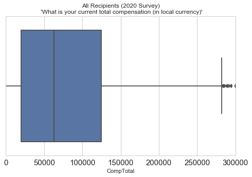

```python
sns.set(context='notebook', style='whitegrid', palette='deep', font='sans-serif', font_scale=1, rc=None)
plt.figure(figsize=[8, 5])
sns.boxplot(df2020_clean['CompTotal'])
plt.xticks(rotation=0, fontsize=15)
plt.yticks(rotation=0, fontsize=15)
plt.xlim([0, 300000])
plt.title("All Recipients (2020 Survey)\n 'What is your current total compensation (in local currency)'");
plt.show()
```

The distribution of `CompTotal` doesn't give us much economic inside, because saleries are denominated in USD,EUR,GBP and other currencies with different values.

Therefore, we filter for devolopers from the United States.

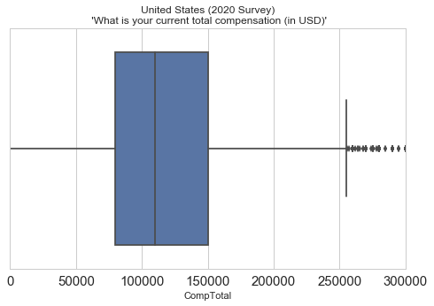

```
count     8.171000e+03
mean     1.359823e+243
std                inf
min       0.000000e+00
25%       8.000000e+04
50%       1.100000e+05
75%       1.500000e+05
max      1.111111e+247
Name: CompTotal, dtype: float64
```

```python
sns.set(context='notebook', style='whitegrid', palette='deep', font='sans-serif', font_scale=1, rc=None)
plt.figure(figsize=[8, 5])
sns.boxplot(df2020_clean[df2020_clean.Country == 'United States']['CompTotal'])
plt.xticks(rotation=0, fontsize=15)
plt.yticks(rotation=0, fontsize=15)
plt.xlim([0, 300000])
plt.title("United States (2020 Survey)\n 'What is your current total compensation (in USD)'");
plt.show()
print(df2020_clean[df2020_clean.Country == 'United States']['CompTotal'].describe());
```

### For developers working in the United States, the median salery is USD 110,000

### and 2.5% of developers in the United States earn more the USD 250,000 annaully.

> Interquartile range (IQR) is USD 80,000 to USD 150,000 .

</font> The whisker of this boxplot (i.e. the vertical lines extending to the most extreme, non-outlier data points) shows that 97.5% of the distribution are below USD 250,000 .

Let us verify the last statement.

```python
(df2020_clean[df2020_clean.Country == 'United States']['CompTotal'] > 250000).sum() /  \
    df2020_clean[df2020_clean.Country == 'United States'].shape[0]
```

```
0.025583446948432113
```

## **ConvertedComp** (Definition) </font>**2020 survey**

> Salary converted to annual USD salaries using the exchange rate on 2020-02-19, assuming 12 working months and 50 working weeks.

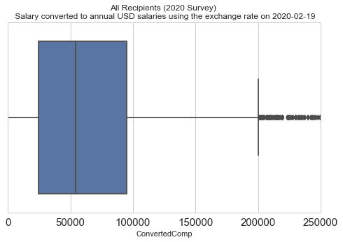

```
count    3.475600e+04
mean     1.037561e+05
std      2.268853e+05
min      0.000000e+00
25%      2.464800e+04
50%      5.404900e+04
75%      9.500000e+04
max      2.000000e+06
Name: ConvertedComp, dtype: float64
```

```python
sns.set(context='notebook', style='whitegrid', palette='deep', font='sans-serif', font_scale=1, rc=None)
plt.figure(figsize=[8, 5])
sns.boxplot(df2020_clean['ConvertedComp'])
plt.xticks(rotation=0, fontsize=15)
plt.yticks(rotation=0, fontsize=15)
plt.xlim([0, 250000])
plt.title("All Recipients (2020 Survey) \n Salary converted to annual USD salaries using the exchange rate on 2020-02-19");
plt.show()
print(df2020_clean.ConvertedComp.describe());
```

### The median salary of all recipients of the 2020 survey converted to annual USD salaries is $54,000

> Interquartile range (IQR) is between USD 25,000 to USD 95,000.  
> </font>

Let us take **Germany** as an example. What is the distribution of saleries for developers in Germany?

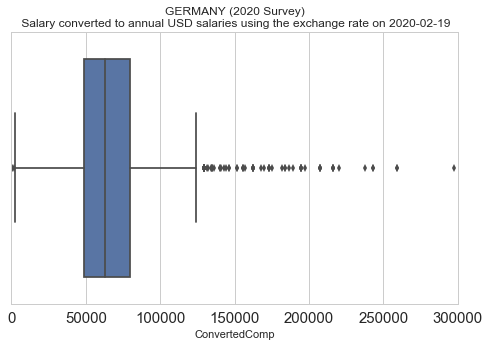

```
count    2.311000e+03
mean     9.250865e+04
std      1.445045e+05
min      2.400000e+01
25%      4.864400e+04
50%      6.269700e+04
75%      7.972250e+04
max      1.200000e+06
Name: ConvertedComp, dtype: float64
```

```python
sns.set(context='notebook', style='whitegrid', palette='deep', font='sans-serif', font_scale=1, rc=None)
plt.figure(figsize=[8, 5])
sns.boxplot(df2020_clean[df2020_clean.Country == 'Germany']['ConvertedComp'])
plt.xticks(rotation=0, fontsize=15)
plt.yticks(rotation=0, fontsize=15)
plt.xlim([0, 300000])
plt.title("GERMANY (2020 Survey)\n Salary converted to annual USD salaries using the exchange rate on 2020-02-19");
plt.show()
print(df2020_clean[df2020_clean.Country == 'Germany']['ConvertedComp'].describe());
```

### The median salary of German developers in the 2020 survey converted to USD salaries is $63,000 annually.

> Interquartile range (IQR) is between USD 48,000 to USD 78,000. About 2.5 percent eran more than USD 120,000 per year.  
> </font>

# IV. Exploration of categorical variables

## **Country** (Definition) </font>**2018 and 2020 survey**

> Where do you live?

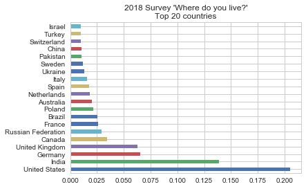

```python
country_vals2018 = df2018.Country.value_counts()#Provide a pandas series of the counts for each unique entry (i.e. countries)

country_allocation2018 = (country_vals2018[:20]/df2018.shape[0])

country_allocation2018.plot(kind="barh");
plt.title("2018 Survey 'Where do you live?'\nTop 20 countries");
```

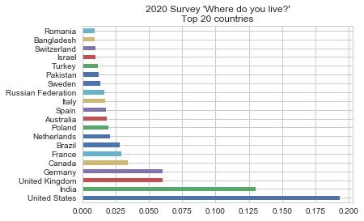

```python
country_vals2020 = df2020.Country.value_counts()# Provide a pandas series of the counts for each unique entry

country_allocation2020 = (country_vals2020[:20]/df2020.shape[0])

country_allocation2020.plot(kind="barh");
plt.title("2020 Survey 'Where do you live?'\nTop 20 countries");
```

### For both the 2018 and 2020 surveys,

> about *20 percent* of recipients come from the **United States**,

> about *13 percent* come from **India**,  
> about *6 percent* from the **United Kingdom** and **Germany**, respectively,  
> and *3 percent* from **Canada**.

Surprisingly, **China** dropped out of the Top 20 list in the 2020 survey, being replaced by **Romania**. Other countries of **The G20 (or Group of Twenty)** that do not appear in the Top 20 are Argentina, Indonesia, Japan, Mexico, Saudi Arabia, South Africa and South Korea.  
</font>  
Collectively, the G20 economies account for around 90% of the gross world product (GWP), 80% of world trade (or, if excluding EU intra-trade, 75%), two-thirds of the world population, and approximately half of the world land area. https://en.wikipedia.org/wiki/G20

As of 2020 there are 20 members of the G20 group: Argentina, Australia, Brazil, Canada, China, the European Union, France, Germany, India, Indonesia, Italy, Japan, Mexico, Russia, Saudi Arabia, South Africa, South Korea, Turkey, the United Kingdom, and the United States. Spain is a permanent guest invitee.

## **EdLevel** (Definition) </font>**2020 survey**

> Which of the following best describes the highest level of formal education that you have completed?

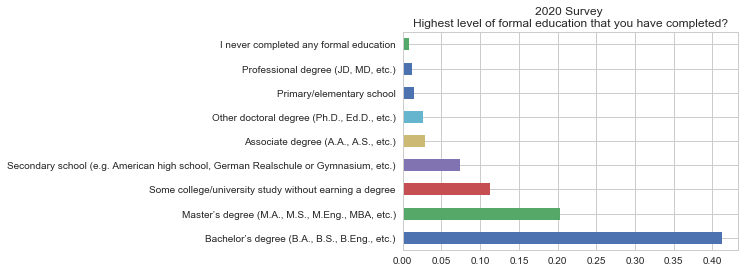

```python
EdLevel_vals = df2020_clean.EdLevel.value_counts()#Provide a pandas series of the counts for each unique entry

(EdLevel_vals/df2020_clean.shape[0]).plot(kind="barh");
plt.title("2020 Survey \nHighest level of formal education that you have completed?");
```

### Most developers in the 2020 survey have studied at a university.

> About 2/3 of recipients have an academic degree (bachelor's, master's or doctoral degrees) or professional degree. However, many developers have successfully entered the field without starting or completing an academic degree first.  
> </font>

## **UndergradMajor** (Definition) </font>**2018 and 2020 survey**

> What was your primary field of study?

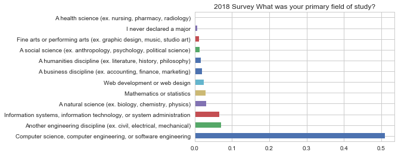

```python
UndergradMajor_vals2018 = df2018.UndergradMajor.value_counts()#Provide a pandas series of the counts for each unique entry


(UndergradMajor_vals2018/df2018.shape[0]).plot(kind="barh");
plt.title("2018 Survey What was your primary field of study?");
```

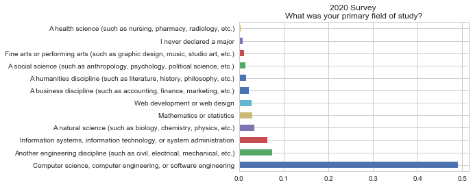

```python
UndergradMajor_vals2020 = df2020_clean.UndergradMajor.value_counts()# Provide a pandas series of the counts
                                                                    # for each unique entry

(UndergradMajor_vals2020/df2020_clean.shape[0]).plot(kind="barh");
plt.title("2020 Survey \nWhat was your primary field of study?");
```

## **Employment** (Definition) </font>**2020 survey**

> Which of the following best describes your current employment status?

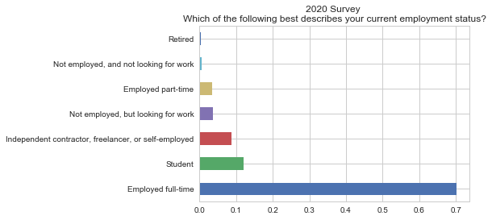

```python
Employment_vals = df2020_clean.Employment.value_counts()#Provide a pandas series of the counts for each unique entry


(Employment_vals/df2020_clean.shape[0]).plot(kind="barh");
plt.title("2020 Survey \nWhich of the following best describes your current employment status?");
```

### Most developers in the 2020 survey are full-time employed, students or work self-employed.

> Only a fraction of respondants is not employed or retired.  
> </font>

## **JobSat** (Definition) </font>**2020 survey**

> How satisfied are you with your current job? (If you work multiple jobs, answer for the one you spend the most hours on.)

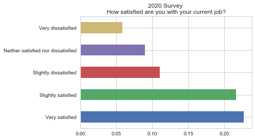

```python
JobSat_vals = df2020_clean.JobSat.value_counts() # Provide a pandas series of the counts for each unique entry


(JobSat_vals/df2020_clean.shape[0]).plot(kind="barh");
plt.title("2020 Survey \nHow satisfied are you with your current job?");
```

### Only half of the developers in the 2020 survey are satisfied with their current job.

**Agile Project Management** methodologies are widespread in software development. The 2020 survey has two new questions dealing with **DevOps**.

> *"DevOps is a set of practices that combines software development (Dev) and IT operations (Ops). It aims to shorten the systems development life cycle and provide continuous delivery with high software quality.DevOps is complementary with Agile software development; several DevOps aspects came from Agile methodology."* https://en.wikipedia.org/wiki/DevOps

## **NEWDevOps** (Definition) </font>**2020 survey**

> Does your company have a dedicated DevOps person?

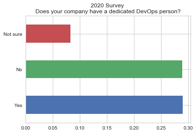

```python
DevOps_vals = df2020_clean.NEWDevOps.value_counts()#Provide a pandas series of the counts for each unique entry


(DevOps_vals/df2020_clean.shape[0]).plot(kind="barh");
plt.title("2020 Survey \nDoes your company have a dedicated DevOps person?");
```

## **NEWDevOpsImpt** (Definition) </font>**2020 survey**

> How important is the practice of DevOps to scaling software development?

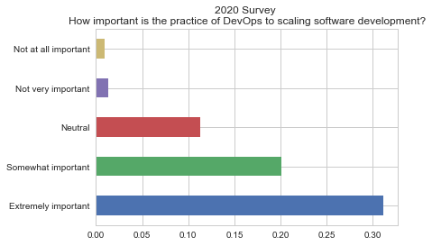

```python
DevOpsImpt_vals = df2020_clean.NEWDevOpsImpt.value_counts()#Provide a pandas series of the counts for each unique entry


(DevOpsImpt_vals/df2020_clean.shape[0]).plot(kind="barh");
plt.title("2020 Survey \nHow important is the practice of DevOps to scaling software development?");
```

### Most developers in the 2020 survey concider DevOps important.

In the 2018 survey there is one question asking specifically about project management methodologies.

## **Methodology** (Definition) </font>**2018 survey only**

> Which Project Management Methodologies Do Developers Use?

```python
df2018.Methodology.nunique()
```

```
480
```

There is a large number of unique entries created by various combination possibilities of options to pick for this question.

Let us find the project management methodologies (i.e. options) to choose from.

```python
ProjectManagement = df2018_clean.Methodology.dropna(axis=0).unique()

txt = []

for i in range(len(ProjectManagement)):
    name = (ProjectManagement[i].split(";"))
    txt.append(name)

ProjectManagement = set(list(chain.from_iterable(txt))) # The data type SET makes sure that
                                              #  project management types only appear once

ProjectManagement # print the set of project management methodologies
```

```
{'Agile',
 'Evidence-based software engineering',
 'Extreme programming (XP)',
 'Formal standard such as ISO 9001 or IEEE 12207 (aka “waterfall” methodologies)',
 'Kanban',
 'Lean',
 'Mob programming',
 'PRINCE2',
 'Pair programming',
 'Scrum'}
```

The variable **`df_2018`** `Methodology` has **n = 10** options to choose from (e.g. `[Agile]`, `[Scrum]`) and respondants can **tick all that apply**. Therefore, the number of *possible* unique entries is\begin{equation} 2^n - 1 = 1023\end{equation}

What is the *observed* number of unique entries?

```python
df2018.Methodology.nunique() #  show no. of unique entries in the column
```

```
480
```

Respondants provide 480 different combinations of the 10 options provided in the multiple choice question of **`df_2018`** `Methodology`. Therefore, about half of the combination possibilities were indeed used. Apparently, project management methodologies can be combined in many ways.

We would like to print a diagram of the share of the different project management methodologies. However, we need to define a **helper function** to count the number of occurrence of each methodology.

```python
# Helper function to count the number of occurrence taken from a lecture of the Udacity Data Science Nanodegree program

def total_count(df, col1, col2, look_for):
    '''
    INPUT:
    df - the pandas dataframe you want to search
    col1 - the column name you want to look through
    col2 - the column you want to count values for
    look_for - a list of strings you want to search for in each row of df[col]

    OUTPUT:
    new_df - a dataframe of each look_for with the count of how often it shows up
    '''
    from collections import defaultdict
    new_df = defaultdict(int)
    for val in look_for:
        for idx in range(df.shape[0]):
            if val in df[col1][idx]:
                new_df[val] += int(df[col2][idx])
    new_df = pd.DataFrame(pd.Series(new_df)).reset_index()
    new_df.columns = [col1, col2]
    new_df.sort_values('count', ascending = False, inplace = True)
    return new_df
```

Let us print a nice looking chart:

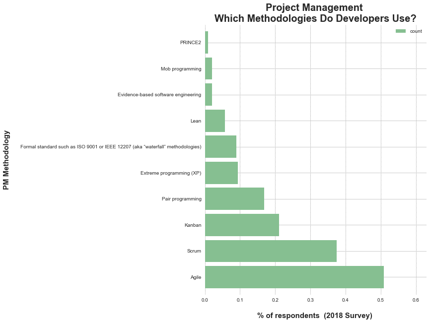

```python
pm_methodes =  list(ProjectManagement)

methodology = df2018_clean['Methodology'].value_counts().reset_index()
methodology.rename(columns={'index': 'pm_methodology', 'Methodology': 'count'}, inplace=True)
methodology_df = total_count(methodology, 'pm_methodology', 'count', pm_methodes)
methodology_df.set_index('pm_methodology', inplace=True)

pm_methodes_share = (methodology_df/df2018_clean.Methodology.shape)

ax = pm_methodes_share.plot(kind='barh', figsize=(8, 10), color='#86bf91', zorder=2, width=0.85)

  # Despine
ax.spines['right'].set_visible(False)
ax.spines['top'].set_visible(False)
ax.spines['left'].set_visible(False)
ax.spines['bottom'].set_visible(False)


  # Draw vertical axis lines
vals = ax.get_xticks()
for tick in vals:
    ax.axvline(x=tick, linestyle='dashed', alpha=0.4, color='#eeeeee', zorder=1)

  # Set x-axis label
ax.set_xlabel("% of respondents  (2018 Survey) ", labelpad=20, weight='bold', size=15)

  # Set y-axis label
ax.set_ylabel("PM Methodology", labelpad=20, weight='bold', size=15)


plt.title('Project Management \nWhich Methodologies Do Developers Use?', weight='bold', size=20);
plt.show()
```

### Agile and Scrum are the most popular project management methodologies for software developers.

> Only a fraction of respondants use traditional project management methodologies (aka 'waterfall' methodologies). However, the Kanban methodology originally developed in manufacturing (Toyota) is popular with software developers as well.  
> </font>

## **PurchaseWhat** (Definition) </font>**2020 survey**

> What level of influence do you, personally, have over new technology purchases at your organization?

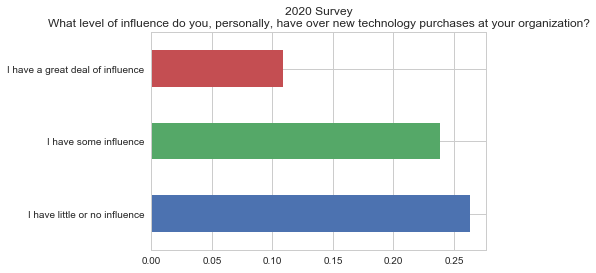

```python
PurchaseWhat_vals = df2020_clean.PurchaseWhat.value_counts()#Provide a pandas series of the counts for each unique entry
(PurchaseWhat_vals/df2020_clean.shape[0]).plot(kind="barh");
plt.title("2020 Survey\nWhat level of influence do you, personally, have over new technology purchases at your organization?");
```

## **SOAccount** (Definition) </font>**2020 survey**

> Do you have a Stack Overflow account?

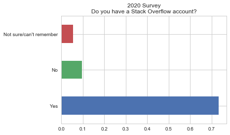

```python
SOAccount_vals = df2020_clean.SOAccount.value_counts()#Provide a pandas series of the counts for each unique entry
(SOAccount_vals/df2020_clean.shape[0]).plot(kind="barh");
plt.title("2020 Survey\nDo you have a Stack Overflow account?");
```

## **SOComm** (Definition) </font>**2020 survey**

> Do you consider yourself a member of the Stack Overflow community?

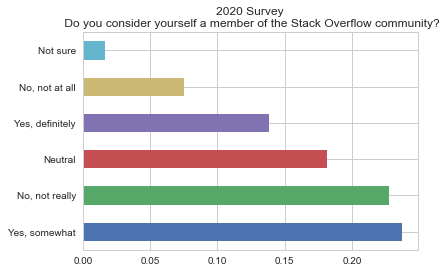

```python
SOComm_vals = df2020_clean.SOComm.value_counts()#Provide a pandas series of the counts for each unique entry
(SOComm_vals/df2020_clean.shape[0]).plot(kind="barh");
plt.title("2020 Survey\n Do you consider yourself a member of the Stack Overflow community?");
```

## **SOPartFreq** (Definition) </font>**2020 survey**

> How frequently would you say you participate in Q&A on Stack Overflow? By participate we mean ask, answer, vote for, or comment on questions.

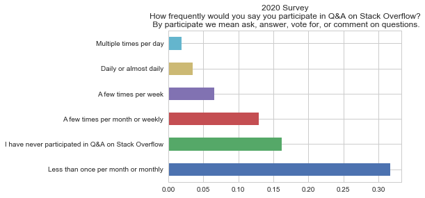

```python
SOPartFreq_vals = df2020_clean.SOPartFreq.value_counts()#Provide a pandas series of the counts for each unique entry
(SOPartFreq_vals/df2020_clean.shape[0]).plot(kind="barh");
plt.title("2020 Survey\nHow frequently would you say you participate in Q&A on Stack Overflow?\n By participate we mean ask, answer, vote for, or comment on questions.");
```

## **SOVisitFreq** (Definition) </font>**2030 survey**

> How frequently would you say you visit Stack Overflow?

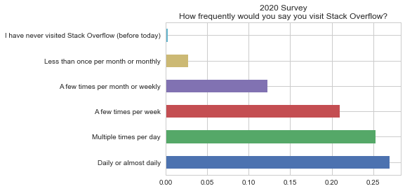

```python
SOVisitFreq_vals = df2020_clean.SOVisitFreq.value_counts()#Provide a pandas series of the counts for each unique entry
(SOVisitFreq_vals/df2020_clean.shape[0]).plot(kind="barh");
plt.title("2020 Survey\nHow frequently would you say you visit Stack Overflow?");
```

## **NEWPurpleLink** (Definition) </font>**2020 survey**

> You search for a coding solution online and the first result link is purple because you already visited it. How do you feel?

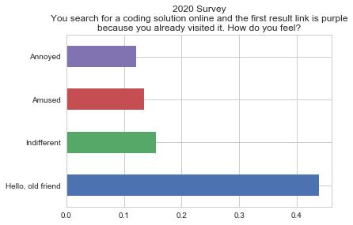

```python
PurpleLink_vals = df2020_clean.NEWPurpleLink.value_counts()#Provide a pandas series of the counts for each unique entry
(PurpleLink_vals/df2020_clean.shape[0]).plot(kind="barh");
plt.title("2020 Survey\nYou search for a coding solution online and the first result link is purple\
\nbecause you already visited it. How do you feel?");
```

## **SurveyLength** (Definition) </font>**2020 survey**

> How do you feel about the length of the survey this year?

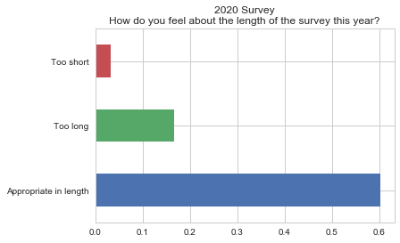

```python
SurveyLength_vals = df2020_clean.SurveyLength.value_counts()#Provide a pandas series of the counts for each unique entry
(SurveyLength_vals/df2020_clean.shape[0]).plot(kind="barh");
plt.title("2020 Survey\nHow do you feel about the length of the survey this year?");
```

## **Trans** (Definition) </font>**2020 survey**

> Are you transgender?

```
No     0.758148
Yes    0.007353
Name: Trans, dtype: float64
```

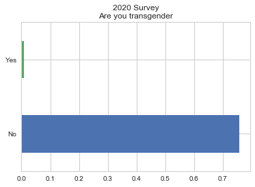

```python
Trans_vals = df2020_clean.Trans.value_counts()#Provide a pandas series of the counts for each unique entry
(Trans_vals/df2020_clean.shape[0]).plot(kind="barh");
plt.title("2020 Survey\nAre you transgender");
(Trans_vals/df2020_clean.shape[0])
```

## **WelcomeChange** (Definition) </font>**2020 survey**

> Compared to last year, how welcome do you feel on Stack Overflow?

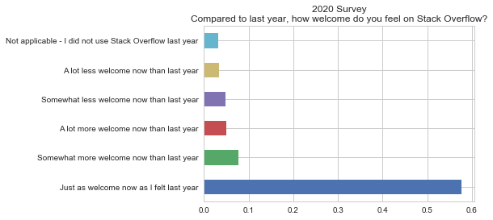

```python
WelcomeChange_vals = df2020_clean.WelcomeChange.value_counts()#Provide a pandas series of the counts for each FormalEducation status
(WelcomeChange_vals/df2020_clean.shape[0]).plot(kind="barh");
plt.title("2020 Survey\nCompared to last year, how welcome do you feel on Stack Overflow?");
```

### Most respondants in the 2020 survey feel welcome on the Stack Overflow webside.

Let us exlore the different **Developer Roles** performed by the respondants of the 2020 survey.

We will be using the dataframe **`df2020_DevType`** that consists of the column `DevType` and the 23 boolean variables mapped from **`df2020`** `DevType`.

```python
df2020_DevType
```

[output not shown]